# Results: Program 1

The CONTENTS Procedure

| Data Set Name | WORK.IMPORT2 | Observations | 18900 |
| --- | --- | --- | --- |
| Member Type | DATA | Variables | 160 |
| Engine | V9 | Indexes | 0 |
| Created | 03/19/2025 20:33:58 | Observation Length | 1304 |
| Last Modified | 03/19/2025 20:33:58 | Deleted Observations | 0 |
| Protection |  | Compressed | NO |
| Data Set Type |  | Sorted | NO |
| Label |  |  |  |
| Data Representation | SOLARIS_X86_64, LINUX_X86_64, ALPHA_TRU64, LINUX_IA64 |  |  |
| Encoding | utf-8 Unicode (UTF-8) |  |  |

| Engine/Host Dependent Information |  |
| --- | --- |
| Data Set Page Size | 131072 |
| Number of Data Set Pages | 190 |
| First Data Page | 1 |
| Max Obs per Page | 100 |
| Obs in First Data Page | 82 |
| Number of Data Set Repairs | 0 |
| Filename | /saswork/SAS_work68B200015B8D_odaws02-usw2.oda.sas.com/SAS_workD5AE00015B8D_odaws02-usw2.oda.sas.com/import2.sas7bdat |
| Release Created | 9.0401M7 |
| Host Created | Linux |
| Inode Number | 536941901 |
| Access Permission | rw-r--r-- |
| Owner Name | u64189948 |
| File Size | 24MB |
| File Size (bytes) | 25034752 |

| Alphabetic List of Variables and Attributes # | Alphabetic List of Variables and Attributes Variable | Alphabetic List of Variables and Attributes Type | Alphabetic List of Variables and Attributes Len | Alphabetic List of Variables and Attributes Format | Alphabetic List of Variables and Attributes Informat |
| --- | --- | --- | --- | --- | --- |
| 7 | Age | Num | 8 | BEST12. | BEST32. |
| 32 | CIO_BetterTense | Num | 8 | BEST12. | BEST32. |
| 31 | CIO_Competition | Num | 8 | BEST12. | BEST32. |
| 36 | CIO_Cooperate | Num | 8 | BEST12. | BEST32. |
| 38 | CIO_Family | Num | 8 | BEST12. | BEST32. |
| 29 | CIO_Identity | Num | 8 | BEST12. | BEST32. |
| 30 | CIO_JobBetter | Num | 8 | BEST12. | BEST32. |
| 28 | CIO_OwnThing | Num | 8 | BEST12. | BEST32. |
| 37 | CIO_ParentsChildren | Num | 8 | BEST12. | BEST32. |
| 33 | CIO_PeerPrize | Num | 8 | BEST12. | BEST32. |
| 34 | CIO_PeerWellbeing | Num | 8 | BEST12. | BEST32. |
| 35 | CIO_PleasureTime | Num | 8 | BEST12. | BEST32. |
| 39 | CIO_RespectGrpDecisions | Num | 8 | BEST12. | BEST32. |
| 26 | CIO_SelfDepend | Num | 8 | BEST12. | BEST32. |
| 27 | CIO_SelfDependMost | Num | 8 | BEST12. | BEST32. |
| 15 | Children | Num | 8 | BEST12. | BEST32. |
| 3 | Country | Num | 8 | BEST12. | BEST32. |
| 9 | DegreeYear | Num | 8 | BEST12. | BEST32. |
| 135 | ER_EmotionControl | Num | 8 | BEST12. | BEST32. |
| 132 | ER_ExpressPositive | Num | 8 | BEST12. | BEST32. |
| 137 | ER_LessNegative | Num | 8 | BEST12. | BEST32. |
| 136 | ER_NegativeExpress | Num | 8 | BEST12. | BEST32. |
| 131 | ER_NegativeThink | Num | 8 | BEST12. | BEST32. |
| 134 | ER_PositiveChange | Num | 8 | BEST12. | BEST32. |
| 130 | ER_PositiveThink | Num | 8 | BEST12. | BEST32. |
| 133 | ER_StressCalm | Num | 8 | BEST12. | BEST32. |
| 10 | Education | Num | 8 | BEST12. | BEST32. |
| 141 | Empathy_Criticizing | Num | 8 | BEST12. | BEST32. |
| 143 | Empathy_Difficult | Num | 8 | BEST12. | BEST32. |
| 138 | Empathy_Perspective | Num | 8 | BEST12. | BEST32. |

[output cut: 130 more lines]

The CONTENTS Procedure

| Data Set Name | WORK.IMPORT2 | Observations | 18900 |
| --- | --- | --- | --- |
| Member Type | DATA | Variables | 160 |
| Engine | V9 | Indexes | 0 |
| Created | 03/19/2025 20:33:58 | Observation Length | 1304 |
| Last Modified | 03/19/2025 20:33:58 | Deleted Observations | 0 |
| Protection |  | Compressed | NO |
| Data Set Type |  | Sorted | NO |
| Label |  |  |  |
| Data Representation | SOLARIS_X86_64, LINUX_X86_64, ALPHA_TRU64, LINUX_IA64 |  |  |
| Encoding | utf-8 Unicode (UTF-8) |  |  |

| Engine/Host Dependent Information |  |
| --- | --- |
| Data Set Page Size | 131072 |
| Number of Data Set Pages | 190 |
| First Data Page | 1 |
| Max Obs per Page | 100 |
| Obs in First Data Page | 82 |
| Number of Data Set Repairs | 0 |
| Filename | /saswork/SAS_work68B200015B8D_odaws02-usw2.oda.sas.com/SAS_workD5AE00015B8D_odaws02-usw2.oda.sas.com/import2.sas7bdat |
| Release Created | 9.0401M7 |
| Host Created | Linux |
| Inode Number | 536941901 |
| Access Permission | rw-r--r-- |
| Owner Name | u64189948 |
| File Size | 24MB |
| File Size (bytes) | 25034752 |

| Alphabetic List of Variables and Attributes # | Alphabetic List of Variables and Attributes Variable | Alphabetic List of Variables and Attributes Type | Alphabetic List of Variables and Attributes Len | Alphabetic List of Variables and Attributes Format | Alphabetic List of Variables and Attributes Informat |
| --- | --- | --- | --- | --- | --- |
| 7 | Age | Num | 8 | BEST12. | BEST32. |
| 32 | CIO_BetterTense | Num | 8 | BEST12. | BEST32. |
| 31 | CIO_Competition | Num | 8 | BEST12. | BEST32. |
| 36 | CIO_Cooperate | Num | 8 | BEST12. | BEST32. |
| 38 | CIO_Family | Num | 8 | BEST12. | BEST32. |
| 29 | CIO_Identity | Num | 8 | BEST12. | BEST32. |
| 30 | CIO_JobBetter | Num | 8 | BEST12. | BEST32. |
| 28 | CIO_OwnThing | Num | 8 | BEST12. | BEST32. |
| 37 | CIO_ParentsChildren | Num | 8 | BEST12. | BEST32. |
| 33 | CIO_PeerPrize | Num | 8 | BEST12. | BEST32. |
| 34 | CIO_PeerWellbeing | Num | 8 | BEST12. | BEST32. |
| 35 | CIO_PleasureTime | Num | 8 | BEST12. | BEST32. |
| 39 | CIO_RespectGrpDecisions | Num | 8 | BEST12. | BEST32. |
| 26 | CIO_SelfDepend | Num | 8 | BEST12. | BEST32. |
| 27 | CIO_SelfDependMost | Num | 8 | BEST12. | BEST32. |
| 15 | Children | Num | 8 | BEST12. | BEST32. |
| 3 | Country | Num | 8 | BEST12. | BEST32. |
| 9 | DegreeYear | Num | 8 | BEST12. | BEST32. |
| 135 | ER_EmotionControl | Num | 8 | BEST12. | BEST32. |
| 132 | ER_ExpressPositive | Num | 8 | BEST12. | BEST32. |
| 137 | ER_LessNegative | Num | 8 | BEST12. | BEST32. |
| 136 | ER_NegativeExpress | Num | 8 | BEST12. | BEST32. |
| 131 | ER_NegativeThink | Num | 8 | BEST12. | BEST32. |
| 134 | ER_PositiveChange | Num | 8 | BEST12. | BEST32. |
| 130 | ER_PositiveThink | Num | 8 | BEST12. | BEST32. |
| 133 | ER_StressCalm | Num | 8 | BEST12. | BEST32. |
| 10 | Education | Num | 8 | BEST12. | BEST32. |
| 141 | Empathy_Criticizing | Num | 8 | BEST12. | BEST32. |
| 143 | Empathy_Difficult | Num | 8 | BEST12. | BEST32. |
| 138 | Empathy_Perspective | Num | 8 | BEST12. | BEST32. |

[output cut: 130 more lines]

The MEANS Procedure

| Analysis Variable : Age N | Analysis Variable : Age N Miss | Analysis Variable : Age Mean | Analysis Variable : Age Std Dev | Analysis Variable : Age Minimum | Analysis Variable : Age Maximum |
| --- | --- | --- | --- | --- | --- |
| 18900 | 0 | 2.3322222 | 7.4471629 | 1.0000000 | 99.0000000 |

The FREQ Procedure

| Source | Frequency | Percent | Cumulative Frequency | Cumulative Percent |
| --- | --- | --- | --- | --- |
| 1 | 11391 | 60.27 | 11391 | 60.27 |
| 2 | 2218 | 11.74 | 13609 | 72.01 |
| 3 | 593 | 3.14 | 14202 | 75.14 |
| 4 | 4698 | 24.86 | 18900 | 100.00 |

| Gender | Frequency | Percent | Cumulative Frequency | Cumulative Percent |
| --- | --- | --- | --- | --- |
| 0 | 10868 | 57.50 | 10868 | 57.50 |
| 1 | 7958 | 42.11 | 18826 | 99.61 |
| 9 | 74 | 0.39 | 18900 | 100.00 |

The MEANS Procedure

| Analysis Variable : Age Source | Analysis Variable : Age Gender | Analysis Variable : Age N Obs | Analysis Variable : Age N | Analysis Variable : Age Mean | Analysis Variable : Age Std Dev | Analysis Variable : Age Minimum | Analysis Variable : Age Maximum |
| --- | --- | --- | --- | --- | --- | --- | --- |
| 1 | 0 | 6656 | 6656 | 1.4639423 | 5.8809035 | 1.0000000 | 99.0000000 |
|  | 1 | 4691 | 4691 | 1.5363462 | 6.0646930 | 1.0000000 | 99.0000000 |
|  | 9 | 44 | 44 | 30.0909091 | 45.1410287 | 1.0000000 | 99.0000000 |
| 2 | 0 | 1270 | 1270 | 4.4236220 | 7.1274611 | 1.0000000 | 99.0000000 |
|  | 1 | 939 | 939 | 4.4323749 | 7.6692318 | 1.0000000 | 99.0000000 |
|  | 9 | 9 | 9 | 46.0000000 | 50.2891638 | 2.0000000 | 99.0000000 |
| 3 | 0 | 249 | 249 | 4.2530120 | 6.1194627 | 2.0000000 | 99.0000000 |
|  | 1 | 341 | 341 | 4.5835777 | 7.3394318 | 2.0000000 | 99.0000000 |
|  | 9 | 3 | 3 | 67.0000000 | 55.4256258 | 3.0000000 | 99.0000000 |
| 4 | 0 | 2693 | 2693 | 2.3052358 | 5.2930151 | 1.0000000 | 99.0000000 |
|  | 1 | 1987 | 1987 | 2.7060896 | 7.5250624 | 1.0000000 | 99.0000000 |
|  | 9 | 18 | 18 | 66.7777778 | 46.8923116 | 2.0000000 | 99.0000000 |

The CONTENTS Procedure

| Data Set Name | WORK.IMPORT2_CLEANED | Observations | 11391 |
| --- | --- | --- | --- |
| Member Type | DATA | Variables | 128 |
| Engine | V9 | Indexes | 0 |
| Created | 03/19/2025 21:11:45 | Observation Length | 1024 |
| Last Modified | 03/19/2025 21:11:45 | Deleted Observations | 0 |
| Protection |  | Compressed | NO |
| Data Set Type |  | Sorted | NO |
| Label |  |  |  |
| Data Representation | SOLARIS_X86_64, LINUX_X86_64, ALPHA_TRU64, LINUX_IA64 |  |  |
| Encoding | utf-8 Unicode (UTF-8) |  |  |

| Engine/Host Dependent Information |  |
| --- | --- |
| Data Set Page Size | 131072 |
| Number of Data Set Pages | 90 |
| First Data Page | 1 |
| Max Obs per Page | 127 |
| Obs in First Data Page | 108 |
| Number of Data Set Repairs | 0 |
| Filename | /saswork/SAS_work68B200015B8D_odaws02-usw2.oda.sas.com/SAS_workD5AE00015B8D_odaws02-usw2.oda.sas.com/import2_cleaned.sas7bdat |
| Release Created | 9.0401M7 |
| Host Created | Linux |
| Inode Number | 536890177 |
| Access Permission | rw-r--r-- |
| Owner Name | u64189948 |
| File Size | 11MB |
| File Size (bytes) | 11927552 |

| Alphabetic List of Variables and Attributes # | Alphabetic List of Variables and Attributes Variable | Alphabetic List of Variables and Attributes Type | Alphabetic List of Variables and Attributes Len | Alphabetic List of Variables and Attributes Format | Alphabetic List of Variables and Attributes Informat |
| --- | --- | --- | --- | --- | --- |
| 4 | Age | Num | 8 | BEST12. | BEST32. |
| 21 | CIO_BetterTense | Num | 8 | BEST12. | BEST32. |
| 20 | CIO_Competition | Num | 8 | BEST12. | BEST32. |
| 25 | CIO_Cooperate | Num | 8 | BEST12. | BEST32. |
| 27 | CIO_Family | Num | 8 | BEST12. | BEST32. |
| 18 | CIO_Identity | Num | 8 | BEST12. | BEST32. |
| 19 | CIO_JobBetter | Num | 8 | BEST12. | BEST32. |
| 17 | CIO_OwnThing | Num | 8 | BEST12. | BEST32. |
| 26 | CIO_ParentsChildren | Num | 8 | BEST12. | BEST32. |
| 22 | CIO_PeerPrize | Num | 8 | BEST12. | BEST32. |
| 23 | CIO_PeerWellbeing | Num | 8 | BEST12. | BEST32. |
| 24 | CIO_PleasureTime | Num | 8 | BEST12. | BEST32. |
| 28 | CIO_RespectGrpDecisions | Num | 8 | BEST12. | BEST32. |
| 15 | CIO_SelfDepend | Num | 8 | BEST12. | BEST32. |
| 16 | CIO_SelfDependMost | Num | 8 | BEST12. | BEST32. |
| 2 | Country | Num | 8 | BEST12. | BEST32. |
| 103 | ER_EmotionControl | Num | 8 | BEST12. | BEST32. |
| 100 | ER_ExpressPositive | Num | 8 | BEST12. | BEST32. |
| 105 | ER_LessNegative | Num | 8 | BEST12. | BEST32. |
| 104 | ER_NegativeExpress | Num | 8 | BEST12. | BEST32. |
| 99 | ER_NegativeThink | Num | 8 | BEST12. | BEST32. |
| 102 | ER_PositiveChange | Num | 8 | BEST12. | BEST32. |
| 98 | ER_PositiveThink | Num | 8 | BEST12. | BEST32. |
| 101 | ER_StressCalm | Num | 8 | BEST12. | BEST32. |
| 109 | Empathy_Criticizing | Num | 8 | BEST12. | BEST32. |
| 111 | Empathy_Difficult | Num | 8 | BEST12. | BEST32. |
| 106 | Empathy_Perspective | Num | 8 | BEST12. | BEST32. |
| 112 | Empathy_Sides | Num | 8 | BEST12. | BEST32. |
| 107 | Empathy_TwoSides | Num | 8 | BEST12. | BEST32. |
| 108 | Empathy_Upset | Num | 8 | BEST12. | BEST32. |

[output cut: 98 more lines]

The MEANS Procedure

[output not shown]

The FREQ Procedure

| Source | Frequency | Percent | Cumulative Frequency | Cumulative Percent |
| --- | --- | --- | --- | --- |
| 1 | 7152 | 100.00 | 7152 | 100.00 |

| Country | Frequency | Percent | Cumulative Frequency | Cumulative Percent |
| --- | --- | --- | --- | --- |
| 1 | 535 | 7.48 | 535 | 7.48 |
| 2 | 311 | 4.35 | 846 | 11.83 |
| 4 | 658 | 9.20 | 1504 | 21.03 |
| 5 | 260 | 3.64 | 1764 | 24.66 |
| 6 | 425 | 5.94 | 2189 | 30.61 |
| 7 | 499 | 6.98 | 2688 | 37.58 |
| 8 | 765 | 10.70 | 3453 | 48.28 |
| 10 | 1746 | 24.41 | 5199 | 72.69 |
| 11 | 417 | 5.83 | 5616 | 78.52 |
| 12 | 355 | 4.96 | 5971 | 83.49 |
| 13 | 249 | 3.48 | 6220 | 86.97 |
| 14 | 727 | 10.16 | 6947 | 97.13 |
| 15 | 205 | 2.87 | 7152 | 100.00 |

| Gender | Frequency | Percent | Cumulative Frequency | Cumulative Percent |
| --- | --- | --- | --- | --- |
| 0 | 4284 | 59.90 | 4284 | 59.90 |
| 1 | 2868 | 40.10 | 7152 | 100.00 |

| Age | Frequency | Percent | Cumulative Frequency | Cumulative Percent |
| --- | --- | --- | --- | --- |
| 1 | 6495 | 90.81 | 6495 | 90.81 |
| 2 | 631 | 8.82 | 7126 | 99.64 |
| 3 | 15 | 0.21 | 7141 | 99.85 |
| 4 | 5 | 0.07 | 7146 | 99.92 |
| 6 | 1 | 0.01 | 7147 | 99.93 |
| 7 | 2 | 0.03 | 7149 | 99.96 |
| 8 | 3 | 0.04 | 7152 | 100.00 |

| Ethnicity | Frequency | Percent | Cumulative Frequency | Cumulative Percent |
| --- | --- | --- | --- | --- |
| 1 | 484 | 6.77 | 484 | 6.77 |
| 2 | 25 | 0.35 | 509 | 7.12 |
| 3 | 14 | 0.20 | 523 | 7.31 |
| 4 | 14 | 0.20 | 537 | 7.51 |
| 5 | 98 | 1.37 | 635 | 8.88 |
| 6 | 72 | 1.01 | 707 | 9.89 |
| 7 | 313 | 4.38 | 1020 | 14.26 |
| 8 | 199 | 2.78 | 1219 | 17.04 |
| 10 | 247 | 3.45 | 1466 | 20.50 |
| 11 | 2 | 0.03 | 1468 | 20.53 |
| 13 | 761 | 10.64 | 2229 | 31.17 |
| 15 | 1 | 0.01 | 2230 | 31.18 |
| 16 | 138 | 1.93 | 2368 | 33.11 |
| 17 | 11 | 0.15 | 2379 | 33.26 |
| 18 | 82 | 1.15 | 2461 | 34.41 |
| 19 | 504 | 7.05 | 2965 | 41.46 |
| 20 | 168 | 2.35 | 3133 | 43.81 |
| 21 | 51 | 0.71 | 3184 | 44.52 |
| 25 | 52 | 0.73 | 3236 | 45.25 |
| 26 | 13 | 0.18 | 3249 | 45.43 |
| 27 | 60 | 0.84 | 3309 | 46.27 |
| 28 | 255 | 3.57 | 3564 | 49.83 |
| 29 | 373 | 5.22 | 3937 | 55.05 |
| 31 | 22 | 0.31 | 3959 | 55.36 |
| 32 | 17 | 0.24 | 3976 | 55.59 |
| 33 | 33 | 0.46 | 4009 | 56.05 |
| 34 | 548 | 7.66 | 4557 | 63.72 |
| 35 | 20 | 0.28 | 4577 | 64.00 |
| 38 | 1730 | 24.19 | 6307 | 88.19 |
| 39 | 7 | 0.10 | 6314 | 88.28 |
| 40 | 2 | 0.03 | 6316 | 88.31 |
| 41 | 287 | 4.01 | 6603 | 92.32 |
| 42 | 38 | 0.53 | 6641 | 92.86 |
| 43 | 5 | 0.07 | 6646 | 92.93 |
| 44 | 506 | 7.07 | 7152 | 100.00 |

| Forgive_Car | Frequency | Percent | Cumulative Frequency | Cumulative Percent |
| --- | --- | --- | --- | --- |
| 1 | 612 | 8.56 | 612 | 8.56 |
| 2 | 1249 | 17.46 | 1861 | 26.02 |
| 3 | 3462 | 48.41 | 5323 | 74.43 |
| 4 | 1829 | 25.57 | 7152 | 100.00 |

| Forgive_BrokenEngagement | Frequency | Percent | Cumulative Frequency | Cumulative Percent |
| --- | --- | --- | --- | --- |
| 1 | 1977 | 27.64 | 1977 | 27.64 |
| 2 | 2213 | 30.94 | 4190 | 58.59 |
| 3 | 2186 | 30.56 | 6376 | 89.15 |
| 4 | 776 | 10.85 | 7152 | 100.00 |

| Forgive_SecretDisclosure | Frequency | Percent | Cumulative Frequency | Cumulative Percent |
| --- | --- | --- | --- | --- |
| 1 | 1620 | 22.65 | 1620 | 22.65 |
| 2 | 2343 | 32.76 | 3963 | 55.41 |
| 3 | 2474 | 34.59 | 6437 | 90.00 |
| 4 | 715 | 10.00 | 7152 | 100.00 |

| Forgive_CousinArgument | Frequency | Percent | Cumulative Frequency | Cumulative Percent |
| --- | --- | --- | --- | --- |
| 1 | 1552 | 21.70 | 1552 | 21.70 |
| 2 | 2239 | 31.31 | 3791 | 53.01 |
| 3 | 2489 | 34.80 | 6280 | 87.81 |
| 4 | 872 | 12.19 | 7152 | 100.00 |

| Forgive_CurseSameReligion | Frequency | Percent | Cumulative Frequency | Cumulative Percent |
| --- | --- | --- | --- | --- |
| 1 | 2574 | 35.99 | 2574 | 35.99 |
| 2 | 2096 | 29.31 | 4670 | 65.30 |
| 3 | 1707 | 23.87 | 6377 | 89.16 |
| 4 | 775 | 10.84 | 7152 | 100.00 |

| Forgive_CurseDiffReligion | Frequency | Percent | Cumulative Frequency | Cumulative Percent |
| --- | --- | --- | --- | --- |
| 1 | 2197 | 30.72 | 2197 | 30.72 |
| 2 | 2052 | 28.69 | 4249 | 59.41 |
| 3 | 2028 | 28.36 | 6277 | 87.77 |
| 4 | 875 | 12.23 | 7152 | 100.00 |

| Forgive_Wall | Frequency | Percent | Cumulative Frequency | Cumulative Percent |
| --- | --- | --- | --- | --- |
| 1 | 1142 | 15.97 | 1142 | 15.97 |
| 2 | 2183 | 30.52 | 3325 | 46.49 |
| 3 | 2829 | 39.56 | 6154 | 86.05 |
| 4 | 998 | 13.95 | 7152 | 100.00 |

| Forgive_Rumor | Frequency | Percent | Cumulative Frequency | Cumulative Percent |
| --- | --- | --- | --- | --- |
| 1 | 2885 | 40.34 | 2885 | 40.34 |
| 2 | 1977 | 27.64 | 4862 | 67.98 |
| 3 | 1581 | 22.11 | 6443 | 90.09 |
| 4 | 709 | 9.91 | 7152 | 100.00 |

| Forgive_Loss | Frequency | Percent | Cumulative Frequency | Cumulative Percent |
| --- | --- | --- | --- | --- |
| 1 | 1591 | 22.25 | 1591 | 22.25 |
| 2 | 2422 | 33.86 | 4013 | 56.11 |
| 3 | 2218 | 31.01 | 6231 | 87.12 |
| 4 | 921 | 12.88 | 7152 | 100.00 |

| CIO_SelfDepend | Frequency | Percent | Cumulative Frequency | Cumulative Percent |
| --- | --- | --- | --- | --- |
| 1 | 442 | 6.18 | 442 | 6.18 |
| 2 | 1779 | 24.87 | 2221 | 31.05 |
| 3 | 2384 | 33.33 | 4605 | 64.39 |
| 4 | 2547 | 35.61 | 7152 | 100.00 |

| CIO_SelfDependMost | Frequency | Percent | Cumulative Frequency | Cumulative Percent |
| --- | --- | --- | --- | --- |
| 1 | 404 | 5.65 | 404 | 5.65 |
| 2 | 2430 | 33.98 | 2834 | 39.63 |
| 3 | 2600 | 36.35 | 5434 | 75.98 |
| 4 | 1718 | 24.02 | 7152 | 100.00 |

| CIO_OwnThing | Frequency | Percent | Cumulative Frequency | Cumulative Percent |
| --- | --- | --- | --- | --- |
| 1 | 250 | 3.50 | 250 | 3.50 |
| 2 | 1645 | 23.00 | 1895 | 26.50 |
| 3 | 2684 | 37.53 | 4579 | 64.02 |
| 4 | 2573 | 35.98 | 7152 | 100.00 |

| CIO_Identity | Frequency | Percent | Cumulative Frequency | Cumulative Percent |
| --- | --- | --- | --- | --- |
| 1 | 510 | 7.13 | 510 | 7.13 |
| 2 | 1159 | 16.21 | 1669 | 23.34 |
| 3 | 1946 | 27.21 | 3615 | 50.55 |
| 4 | 3537 | 49.45 | 7152 | 100.00 |

| CIO_JobBetter | Frequency | Percent | Cumulative Frequency | Cumulative Percent |
| --- | --- | --- | --- | --- |
| 1 | 385 | 5.38 | 385 | 5.38 |
| 2 | 1561 | 21.83 | 1946 | 27.21 |
| 3 | 2046 | 28.61 | 3992 | 55.82 |
| 4 | 3160 | 44.18 | 7152 | 100.00 |

| CIO_Competition | Frequency | Percent | Cumulative Frequency | Cumulative Percent |
| --- | --- | --- | --- | --- |
| 1 | 780 | 10.91 | 780 | 10.91 |
| 2 | 1674 | 23.41 | 2454 | 34.31 |
| 3 | 2067 | 28.90 | 4521 | 63.21 |
| 4 | 2631 | 36.79 | 7152 | 100.00 |

| CIO_BetterTense | Frequency | Percent | Cumulative Frequency | Cumulative Percent |
| --- | --- | --- | --- | --- |
| 1 | 1865 | 26.08 | 1865 | 26.08 |
| 2 | 2787 | 38.97 | 4652 | 65.04 |
| 3 | 1571 | 21.97 | 6223 | 87.01 |
| 4 | 929 | 12.99 | 7152 | 100.00 |

| CIO_PeerPrize | Frequency | Percent | Cumulative Frequency | Cumulative Percent |
| --- | --- | --- | --- | --- |
| 1 | 361 | 5.05 | 361 | 5.05 |
| 2 | 1147 | 16.04 | 1508 | 21.09 |
| 3 | 2072 | 28.97 | 3580 | 50.06 |
| 4 | 3572 | 49.94 | 7152 | 100.00 |

| CIO_PeerWellbeing | Frequency | Percent | Cumulative Frequency | Cumulative Percent |
| --- | --- | --- | --- | --- |
| 1 | 247 | 3.45 | 247 | 3.45 |
| 2 | 1133 | 15.84 | 1380 | 19.30 |
| 3 | 2014 | 28.16 | 3394 | 47.46 |
| 4 | 3758 | 52.54 | 7152 | 100.00 |

| CIO_PleasureTime | Frequency | Percent | Cumulative Frequency | Cumulative Percent |
| --- | --- | --- | --- | --- |
| 1 | 353 | 4.94 | 353 | 4.94 |
| 2 | 1776 | 24.83 | 2129 | 29.77 |
| 3 | 2339 | 32.70 | 4468 | 62.47 |
| 4 | 2684 | 37.53 | 7152 | 100.00 |

| CIO_Cooperate | Frequency | Percent | Cumulative Frequency | Cumulative Percent |
| --- | --- | --- | --- | --- |
| 1 | 203 | 2.84 | 203 | 2.84 |
| 2 | 1152 | 16.11 | 1355 | 18.95 |
| 3 | 2284 | 31.94 | 3639 | 50.88 |
| 4 | 3513 | 49.12 | 7152 | 100.00 |

| CIO_ParentsChildren | Frequency | Percent | Cumulative Frequency | Cumulative Percent |
| --- | --- | --- | --- | --- |
| 1 | 233 | 3.26 | 233 | 3.26 |
| 2 | 1136 | 15.88 | 1369 | 19.14 |
| 3 | 1620 | 22.65 | 2989 | 41.79 |
| 4 | 4163 | 58.21 | 7152 | 100.00 |

| CIO_Family | Frequency | Percent | Cumulative Frequency | Cumulative Percent |
| --- | --- | --- | --- | --- |
| 1 | 212 | 2.96 | 212 | 2.96 |
| 2 | 700 | 9.79 | 912 | 12.75 |
| 3 | 1562 | 21.84 | 2474 | 34.59 |
| 4 | 4678 | 65.41 | 7152 | 100.00 |

| CIO_RespectGrpDecisions | Frequency | Percent | Cumulative Frequency | Cumulative Percent |
| --- | --- | --- | --- | --- |
| 1 | 242 | 3.38 | 242 | 3.38 |
| 2 | 1450 | 20.27 | 1692 | 23.66 |
| 3 | 2472 | 34.56 | 4164 | 58.22 |
| 4 | 2988 | 41.78 | 7152 | 100.00 |

| SE_NotTryComplicated | Frequency | Percent | Cumulative Frequency | Cumulative Percent |
| --- | --- | --- | --- | --- |
| 1 | 2234 | 31.24 | 2234 | 31.24 |
| 2 | 3105 | 43.41 | 5339 | 74.65 |
| 3 | 1271 | 17.77 | 6610 | 92.42 |
| 4 | 542 | 7.58 | 7152 | 100.00 |

| SE_AvoidDifficult | Frequency | Percent | Cumulative Frequency | Cumulative Percent |
| --- | --- | --- | --- | --- |
| 1 | 3208 | 44.85 | 3208 | 44.85 |
| 2 | 2563 | 35.84 | 5771 | 80.69 |
| 3 | 909 | 12.71 | 6680 | 93.40 |
| 4 | 472 | 6.60 | 7152 | 100.00 |

| SE_NewGiveUp | Frequency | Percent | Cumulative Frequency | Cumulative Percent |
| --- | --- | --- | --- | --- |
| 1 | 3376 | 47.20 | 3376 | 47.20 |
| 2 | 2496 | 34.90 | 5872 | 82.10 |
| 3 | 880 | 12.30 | 6752 | 94.41 |
| 4 | 400 | 5.59 | 7152 | 100.00 |

| SE_PlansCertain | Frequency | Percent | Cumulative Frequency | Cumulative Percent |
| --- | --- | --- | --- | --- |
| 1 | 212 | 2.96 | 212 | 2.96 |
| 2 | 1327 | 18.55 | 1539 | 21.52 |
| 3 | 2828 | 39.54 | 4367 | 61.06 |
| 4 | 2785 | 38.94 | 7152 | 100.00 |

| SE_KeepTrying | Frequency | Percent | Cumulative Frequency | Cumulative Percent |
| --- | --- | --- | --- | --- |
| 1 | 170 | 2.38 | 170 | 2.38 |
| 2 | 1032 | 14.43 | 1202 | 16.81 |
| 3 | 2401 | 33.57 | 3603 | 50.38 |
| 4 | 3549 | 49.62 | 7152 | 100.00 |

| SE_Unpleasant | Frequency | Percent | Cumulative Frequency | Cumulative Percent |
| --- | --- | --- | --- | --- |
| 1 | 1030 | 14.40 | 1030 | 14.40 |
| 2 | 2244 | 31.38 | 3274 | 45.78 |
| 3 | 2188 | 30.59 | 5462 | 76.37 |
| 4 | 1690 | 23.63 | 7152 | 100.00 |

| SE_RightToWork | Frequency | Percent | Cumulative Frequency | Cumulative Percent |
| --- | --- | --- | --- | --- |
| 1 | 292 | 4.08 | 292 | 4.08 |
| 2 | 1581 | 22.11 | 1873 | 26.19 |
| 3 | 2557 | 35.75 | 4430 | 61.94 |
| 4 | 2722 | 38.06 | 7152 | 100.00 |

| SE_TryHarder | Frequency | Percent | Cumulative Frequency | Cumulative Percent |
| --- | --- | --- | --- | --- |
| 1 | 289 | 4.04 | 289 | 4.04 |
| 2 | 1202 | 16.81 | 1491 | 20.85 |
| 3 | 2150 | 30.06 | 3641 | 50.91 |
| 4 | 3511 | 49.09 | 7152 | 100.00 |

| SE_RarelyAchieve | Frequency | Percent | Cumulative Frequency | Cumulative Percent |
| --- | --- | --- | --- | --- |
| 1 | 1306 | 18.26 | 1306 | 18.26 |
| 2 | 3370 | 47.12 | 4676 | 65.38 |
| 3 | 1634 | 22.85 | 6310 | 88.23 |
| 4 | 842 | 11.77 | 7152 | 100.00 |

| SE_NotCapable | Frequency | Percent | Cumulative Frequency | Cumulative Percent |
| --- | --- | --- | --- | --- |
| 1 | 2147 | 30.02 | 2147 | 30.02 |
| 2 | 3138 | 43.88 | 5285 | 73.90 |
| 3 | 1328 | 18.57 | 6613 | 92.46 |
| 4 | 539 | 7.54 | 7152 | 100.00 |

| SE_DontHandle | Frequency | Percent | Cumulative Frequency | Cumulative Percent |
| --- | --- | --- | --- | --- |
| 1 | 1796 | 25.11 | 1796 | 25.11 |
| 2 | 3483 | 48.70 | 5279 | 73.81 |
| 3 | 1345 | 18.81 | 6624 | 92.62 |
| 4 | 528 | 7.38 | 7152 | 100.00 |

| SE_Insecure | Frequency | Percent | Cumulative Frequency | Cumulative Percent |
| --- | --- | --- | --- | --- |
| 1 | 2439 | 34.10 | 2439 | 34.10 |
| 2 | 2512 | 35.12 | 4951 | 69.23 |
| 3 | 1262 | 17.65 | 6213 | 86.87 |
| 4 | 939 | 13.13 | 7152 | 100.00 |

| PS_ResultsThink | Frequency | Percent | Cumulative Frequency | Cumulative Percent |
| --- | --- | --- | --- | --- |
| 1 | 384 | 5.37 | 384 | 5.37 |
| 2 | 1299 | 18.16 | 1683 | 23.53 |
| 3 | 2204 | 30.82 | 3887 | 54.35 |
| 4 | 3265 | 45.65 | 7152 | 100.00 |

| PS_GatherInfo | Frequency | Percent | Cumulative Frequency | Cumulative Percent |
| --- | --- | --- | --- | --- |
| 1 | 194 | 2.71 | 194 | 2.71 |
| 2 | 1154 | 16.14 | 1348 | 18.85 |
| 3 | 2748 | 38.42 | 4096 | 57.27 |
| 4 | 3056 | 42.73 | 7152 | 100.00 |

| PS_IdentifyOptions | Frequency | Percent | Cumulative Frequency | Cumulative Percent |
| --- | --- | --- | --- | --- |
| 1 | 215 | 3.01 | 215 | 3.01 |
| 2 | 1325 | 18.53 | 1540 | 21.53 |
| 3 | 2825 | 39.50 | 4365 | 61.03 |
| 4 | 2787 | 38.97 | 7152 | 100.00 |

| PS_ExpressThoughts | Frequency | Percent | Cumulative Frequency | Cumulative Percent |
| --- | --- | --- | --- | --- |
| 1 | 387 | 5.41 | 387 | 5.41 |
| 2 | 1989 | 27.81 | 2376 | 33.22 |
| 3 | 2689 | 37.60 | 5065 | 70.82 |
| 4 | 2087 | 29.18 | 7152 | 100.00 |

| PS_GiveReasons | Frequency | Percent | Cumulative Frequency | Cumulative Percent |
| --- | --- | --- | --- | --- |
| 1 | 236 | 3.30 | 236 | 3.30 |
| 2 | 1481 | 20.71 | 1717 | 24.01 |
| 3 | 2550 | 35.65 | 4267 | 59.66 |
| 4 | 2885 | 40.34 | 7152 | 100.00 |

| PS_InfoToSupport | Frequency | Percent | Cumulative Frequency | Cumulative Percent |
| --- | --- | --- | --- | --- |
| 1 | 193 | 2.70 | 193 | 2.70 |
| 2 | 1122 | 15.69 | 1315 | 18.39 |
| 3 | 2525 | 35.30 | 3840 | 53.69 |
| 4 | 3312 | 46.31 | 7152 | 100.00 |

| PS_MoreThanOne | Frequency | Percent | Cumulative Frequency | Cumulative Percent |
| --- | --- | --- | --- | --- |
| 1 | 250 | 3.50 | 250 | 3.50 |
| 2 | 1725 | 24.12 | 1975 | 27.61 |
| 3 | 2624 | 36.69 | 4599 | 64.30 |
| 4 | 2553 | 35.70 | 7152 | 100.00 |

| PS_PlanInfo | Frequency | Percent | Cumulative Frequency | Cumulative Percent |
| --- | --- | --- | --- | --- |
| 1 | 377 | 5.27 | 377 | 5.27 |
| 2 | 1644 | 22.99 | 2021 | 28.26 |
| 3 | 2645 | 36.98 | 4666 | 65.24 |
| 4 | 2486 | 34.76 | 7152 | 100.00 |

| PS_SupportDecisions | Frequency | Percent | Cumulative Frequency | Cumulative Percent |
| --- | --- | --- | --- | --- |
| 1 | 219 | 3.06 | 219 | 3.06 |
| 2 | 1281 | 17.91 | 1500 | 20.97 |
| 3 | 2856 | 39.93 | 4356 | 60.91 |
| 4 | 2796 | 39.09 | 7152 | 100.00 |

| PS_ListenIdeas | Frequency | Percent | Cumulative Frequency | Cumulative Percent |
| --- | --- | --- | --- | --- |
| 1 | 457 | 6.39 | 457 | 6.39 |
| 2 | 1379 | 19.28 | 1836 | 25.67 |
| 3 | 2329 | 32.56 | 4165 | 58.24 |
| 4 | 2987 | 41.76 | 7152 | 100.00 |

| PS_CompareIdeas | Frequency | Percent | Cumulative Frequency | Cumulative Percent |
| --- | --- | --- | --- | --- |
| 1 | 231 | 3.23 | 231 | 3.23 |
| 2 | 1237 | 17.30 | 1468 | 20.53 |
| 3 | 2912 | 40.72 | 4380 | 61.24 |
| 4 | 2772 | 38.76 | 7152 | 100.00 |

| PS_MindOpen | Frequency | Percent | Cumulative Frequency | Cumulative Percent |
| --- | --- | --- | --- | --- |
| 1 | 215 | 3.01 | 215 | 3.01 |
| 2 | 1041 | 14.56 | 1256 | 17.56 |
| 3 | 2417 | 33.79 | 3673 | 51.36 |
| 4 | 3479 | 48.64 | 7152 | 100.00 |

| MM_UnderstandLife | Frequency | Percent | Cumulative Frequency | Cumulative Percent |
| --- | --- | --- | --- | --- |
| 1 | 406 | 5.68 | 406 | 5.68 |
| 2 | 860 | 12.02 | 1266 | 17.70 |
| 3 | 3139 | 43.89 | 4405 | 61.59 |
| 4 | 2747 | 38.41 | 7152 | 100.00 |

| MM_LifeMeaningful | Frequency | Percent | Cumulative Frequency | Cumulative Percent |
| --- | --- | --- | --- | --- |
| 1 | 353 | 4.94 | 353 | 4.94 |
| 2 | 895 | 12.51 | 1248 | 17.45 |
| 3 | 3054 | 42.70 | 4302 | 60.15 |
| 4 | 2850 | 39.85 | 7152 | 100.00 |

| MM_LifesPurpose | Frequency | Percent | Cumulative Frequency | Cumulative Percent |
| --- | --- | --- | --- | --- |
| 1 | 516 | 7.21 | 516 | 7.21 |
| 2 | 1246 | 17.42 | 1762 | 24.64 |
| 3 | 2778 | 38.84 | 4540 | 63.48 |
| 4 | 2612 | 36.52 | 7152 | 100.00 |

| MM_Purpose | Frequency | Percent | Cumulative Frequency | Cumulative Percent |
| --- | --- | --- | --- | --- |
| 1 | 351 | 4.91 | 351 | 4.91 |
| 2 | 1452 | 20.30 | 1803 | 25.21 |
| 3 | 3223 | 45.06 | 5026 | 70.27 |
| 4 | 2126 | 29.73 | 7152 | 100.00 |

| MM_LifeMeaningfulSense | Frequency | Percent | Cumulative Frequency | Cumulative Percent |
| --- | --- | --- | --- | --- |
| 1 | 310 | 4.33 | 310 | 4.33 |
| 2 | 1138 | 15.91 | 1448 | 20.25 |
| 3 | 3333 | 46.60 | 4781 | 66.85 |
| 4 | 2371 | 33.15 | 7152 | 100.00 |

| MM_SatisfyingPurpose | Frequency | Percent | Cumulative Frequency | Cumulative Percent |
| --- | --- | --- | --- | --- |
| 1 | 463 | 6.47 | 463 | 6.47 |
| 2 | 1892 | 26.45 | 2355 | 32.93 |
| 3 | 2965 | 41.46 | 5320 | 74.38 |
| 4 | 1832 | 25.62 | 7152 | 100.00 |

| MM_FeelSignificant | Frequency | Percent | Cumulative Frequency | Cumulative Percent |
| --- | --- | --- | --- | --- |
| 1 | 375 | 5.24 | 375 | 5.24 |
| 2 | 957 | 13.38 | 1332 | 18.62 |
| 3 | 3047 | 42.60 | 4379 | 61.23 |
| 4 | 2773 | 38.77 | 7152 | 100.00 |

| MM_Mission | Frequency | Percent | Cumulative Frequency | Cumulative Percent |
| --- | --- | --- | --- | --- |
| 1 | 528 | 7.38 | 528 | 7.38 |
| 2 | 1095 | 15.31 | 1623 | 22.69 |
| 3 | 3086 | 43.15 | 4709 | 65.84 |
| 4 | 2443 | 34.16 | 7152 | 100.00 |

| MM_NoPurpose | Frequency | Percent | Cumulative Frequency | Cumulative Percent |
| --- | --- | --- | --- | --- |
| 1 | 3109 | 43.47 | 3109 | 43.47 |
| 2 | 2461 | 34.41 | 5570 | 77.88 |
| 3 | 1092 | 15.27 | 6662 | 93.15 |
| 4 | 490 | 6.85 | 7152 | 100.00 |

| MM_LifeMeaning | Frequency | Percent | Cumulative Frequency | Cumulative Percent |
| --- | --- | --- | --- | --- |
| 1 | 836 | 11.69 | 836 | 11.69 |
| 2 | 1636 | 22.87 | 2472 | 34.56 |
| 3 | 3136 | 43.85 | 5608 | 78.41 |
| 4 | 1544 | 21.59 | 7152 | 100.00 |

| SB_PartOfCommunity | Frequency | Percent | Cumulative Frequency | Cumulative Percent |
| --- | --- | --- | --- | --- |
| 1 | 419 | 5.86 | 419 | 5.86 |
| 2 | 1279 | 17.88 | 1698 | 23.74 |
| 3 | 3380 | 47.26 | 5078 | 71.00 |
| 4 | 2074 | 29.00 | 7152 | 100.00 |

| SB_TeachersRespect | Frequency | Percent | Cumulative Frequency | Cumulative Percent |
| --- | --- | --- | --- | --- |
| 1 | 321 | 4.49 | 321 | 4.49 |
| 2 | 858 | 12.00 | 1179 | 16.48 |
| 3 | 3471 | 48.53 | 4650 | 65.02 |
| 4 | 2502 | 34.98 | 7152 | 100.00 |

| SB_TreatedRespect | Frequency | Percent | Cumulative Frequency | Cumulative Percent |
| --- | --- | --- | --- | --- |
| 1 | 336 | 4.70 | 336 | 4.70 |
| 2 | 1110 | 15.52 | 1446 | 20.22 |
| 3 | 3321 | 46.43 | 4767 | 66.65 |
| 4 | 2385 | 33.35 | 7152 | 100.00 |

| SB_AcceptanceHard | Frequency | Percent | Cumulative Frequency | Cumulative Percent |
| --- | --- | --- | --- | --- |
| 1 | 2532 | 35.40 | 2532 | 35.40 |
| 2 | 2804 | 39.21 | 5336 | 74.61 |
| 3 | 1287 | 17.99 | 6623 | 92.60 |
| 4 | 529 | 7.40 | 7152 | 100.00 |

| SB_DontBelong | Frequency | Percent | Cumulative Frequency | Cumulative Percent |
| --- | --- | --- | --- | --- |
| 1 | 2577 | 36.03 | 2577 | 36.03 |
| 2 | 2492 | 34.84 | 5069 | 70.88 |
| 3 | 1395 | 19.51 | 6464 | 90.38 |
| 4 | 688 | 9.62 | 7152 | 100.00 |

| SB_NoticeGood | Frequency | Percent | Cumulative Frequency | Cumulative Percent |
| --- | --- | --- | --- | --- |
| 1 | 317 | 4.43 | 317 | 4.43 |
| 2 | 1175 | 16.43 | 1492 | 20.86 |
| 3 | 3743 | 52.34 | 5235 | 73.20 |
| 4 | 1917 | 26.80 | 7152 | 100.00 |

| SB_FeelDifferent | Frequency | Percent | Cumulative Frequency | Cumulative Percent |
| --- | --- | --- | --- | --- |
| 1 | 1218 | 17.03 | 1218 | 17.03 |
| 2 | 2563 | 35.84 | 3781 | 52.87 |
| 3 | 2236 | 31.26 | 6017 | 84.13 |
| 4 | 1135 | 15.87 | 7152 | 100.00 |

| SB_ProudSchool | Frequency | Percent | Cumulative Frequency | Cumulative Percent |
| --- | --- | --- | --- | --- |
| 1 | 341 | 4.77 | 341 | 4.77 |
| 2 | 910 | 12.72 | 1251 | 17.49 |
| 3 | 2821 | 39.44 | 4072 | 56.94 |
| 4 | 3080 | 43.06 | 7152 | 100.00 |

| SB_LikeMe | Frequency | Percent | Cumulative Frequency | Cumulative Percent |
| --- | --- | --- | --- | --- |
| 1 | 281 | 3.93 | 281 | 3.93 |
| 2 | 1034 | 14.46 | 1315 | 18.39 |
| 3 | 3602 | 50.36 | 4917 | 68.75 |
| 4 | 2235 | 31.25 | 7152 | 100.00 |

| SB_OpinionsSeriously | Frequency | Percent | Cumulative Frequency | Cumulative Percent |
| --- | --- | --- | --- | --- |
| 1 | 524 | 7.33 | 524 | 7.33 |
| 2 | 1822 | 25.48 | 2346 | 32.80 |
| 3 | 3593 | 50.24 | 5939 | 83.04 |
| 4 | 1213 | 16.96 | 7152 | 100.00 |

| SB_TeachersInterested | Frequency | Percent | Cumulative Frequency | Cumulative Percent |
| --- | --- | --- | --- | --- |
| 1 | 531 | 7.42 | 531 | 7.42 |
| 2 | 1826 | 25.53 | 2357 | 32.96 |
| 3 | 3433 | 48.00 | 5790 | 80.96 |
| 4 | 1362 | 19.04 | 7152 | 100.00 |

| SB_CanTalk | Frequency | Percent | Cumulative Frequency | Cumulative Percent |
| --- | --- | --- | --- | --- |
| 1 | 739 | 10.33 | 739 | 10.33 |
| 2 | 1081 | 15.11 | 1820 | 25.45 |
| 3 | 2986 | 41.75 | 4806 | 67.20 |
| 4 | 2346 | 32.80 | 7152 | 100.00 |

| SB_PeopleFriendly | Frequency | Percent | Cumulative Frequency | Cumulative Percent |
| --- | --- | --- | --- | --- |
| 1 | 279 | 3.90 | 279 | 3.90 |
| 2 | 862 | 12.05 | 1141 | 15.95 |
| 3 | 3648 | 51.01 | 4789 | 66.96 |
| 4 | 2363 | 33.04 | 7152 | 100.00 |

| SB_NotInterested | Frequency | Percent | Cumulative Frequency | Cumulative Percent |
| --- | --- | --- | --- | --- |
| 1 | 2863 | 40.03 | 2863 | 40.03 |
| 2 | 2949 | 41.23 | 5812 | 81.26 |
| 3 | 907 | 12.68 | 6719 | 93.95 |
| 4 | 433 | 6.05 | 7152 | 100.00 |

| SB_Activities | Frequency | Percent | Cumulative Frequency | Cumulative Percent |
| --- | --- | --- | --- | --- |
| 1 | 618 | 8.64 | 618 | 8.64 |
| 2 | 1694 | 23.69 | 2312 | 32.33 |
| 3 | 3215 | 44.95 | 5527 | 77.28 |
| 4 | 1625 | 22.72 | 7152 | 100.00 |

| SB_BeMyself | Frequency | Percent | Cumulative Frequency | Cumulative Percent |
| --- | --- | --- | --- | --- |
| 1 | 462 | 6.46 | 462 | 6.46 |
| 2 | 1187 | 16.60 | 1649 | 23.06 |
| 3 | 3430 | 47.96 | 5079 | 71.02 |
| 4 | 2072 | 28.97 | 7151 | 99.99 |
| 8 | 1 | 0.01 | 7152 | 100.00 |

| SB_GoodWork | Frequency | Percent | Cumulative Frequency | Cumulative Percent |
| --- | --- | --- | --- | --- |
| 1 | 267 | 3.73 | 267 | 3.73 |
| 2 | 919 | 12.85 | 1186 | 16.58 |
| 3 | 3874 | 54.17 | 5060 | 70.75 |
| 4 | 2092 | 29.25 | 7152 | 100.00 |

| SB_DifferentSchool | Frequency | Percent | Cumulative Frequency | Cumulative Percent |
| --- | --- | --- | --- | --- |
| 1 | 2747 | 38.41 | 2747 | 38.41 |
| 2 | 2357 | 32.96 | 5104 | 71.36 |
| 3 | 1131 | 15.81 | 6235 | 87.18 |
| 4 | 917 | 12.82 | 7152 | 100.00 |

| RS_Religion | Frequency | Percent | Cumulative Frequency | Cumulative Percent |
| --- | --- | --- | --- | --- |
| 1 | 333 | 4.66 | 333 | 4.66 |
| 2 | 357 | 4.99 | 690 | 9.65 |
| 3 | 1124 | 15.72 | 1814 | 25.36 |
| 4 | 5338 | 74.64 | 7152 | 100.00 |

| RS_Prayer | Frequency | Percent | Cumulative Frequency | Cumulative Percent |
| --- | --- | --- | --- | --- |
| 1 | 311 | 4.35 | 311 | 4.35 |
| 2 | 444 | 6.21 | 755 | 10.56 |
| 3 | 1285 | 17.97 | 2040 | 28.52 |
| 4 | 5112 | 71.48 | 7152 | 100.00 |

| RS_FeelGod | Frequency | Percent | Cumulative Frequency | Cumulative Percent |
| --- | --- | --- | --- | --- |
| 1 | 353 | 4.94 | 353 | 4.94 |
| 2 | 443 | 6.19 | 796 | 11.13 |
| 3 | 1214 | 16.97 | 2010 | 28.10 |
| 4 | 5142 | 71.90 | 7152 | 100.00 |

| RS_ReligionGrp | Frequency | Percent | Cumulative Frequency | Cumulative Percent |
| --- | --- | --- | --- | --- |
| 1 | 642 | 8.98 | 642 | 8.98 |
| 2 | 960 | 13.42 | 1602 | 22.40 |
| 3 | 2212 | 30.93 | 3814 | 53.33 |
| 4 | 3338 | 46.67 | 7152 | 100.00 |

| RS_DefiningYou | Frequency | Percent | Cumulative Frequency | Cumulative Percent |
| --- | --- | --- | --- | --- |
| 1 | 477 | 6.67 | 477 | 6.67 |
| 2 | 689 | 9.63 | 1166 | 16.30 |
| 3 | 1683 | 23.53 | 2849 | 39.84 |
| 4 | 4303 | 60.16 | 7152 | 100.00 |

| Hope_Anxiety | Frequency | Percent | Cumulative Frequency | Cumulative Percent |
| --- | --- | --- | --- | --- |
| 8 | 7152 | 100.00 | 7152 | 100.00 |

| Hope_Fulfilled | Frequency | Percent | Cumulative Frequency | Cumulative Percent |
| --- | --- | --- | --- | --- |
| 8 | 7152 | 100.00 | 7152 | 100.00 |

| Hope_Hopeful | Frequency | Percent | Cumulative Frequency | Cumulative Percent |
| --- | --- | --- | --- | --- |
| 8 | 7152 | 100.00 | 7152 | 100.00 |

| Hope_LifeQuality | Frequency | Percent | Cumulative Frequency | Cumulative Percent |
| --- | --- | --- | --- | --- |
| 8 | 7152 | 100.00 | 7152 | 100.00 |

| Hope_Life | Frequency | Percent | Cumulative Frequency | Cumulative Percent |
| --- | --- | --- | --- | --- |
| 8 | 7152 | 100.00 | 7152 | 100.00 |

| Hope_DifficultTimes | Frequency | Percent | Cumulative Frequency | Cumulative Percent |
| --- | --- | --- | --- | --- |
| 8 | 7152 | 100.00 | 7152 | 100.00 |

| Gratitude_Thankful | Frequency | Percent | Cumulative Frequency | Cumulative Percent |
| --- | --- | --- | --- | --- |
| 1 | 261 | 3.65 | 261 | 3.65 |
| 2 | 291 | 4.07 | 552 | 7.72 |
| 3 | 2220 | 31.04 | 2772 | 38.76 |
| 4 | 4380 | 61.24 | 7152 | 100.00 |

| Gratitude_LongList | Frequency | Percent | Cumulative Frequency | Cumulative Percent |
| --- | --- | --- | --- | --- |
| 1 | 191 | 2.67 | 191 | 2.67 |
| 2 | 734 | 10.26 | 925 | 12.93 |
| 3 | 2615 | 36.56 | 3540 | 49.50 |
| 4 | 3612 | 50.50 | 7152 | 100.00 |

| Gratitude_NotMuch | Frequency | Percent | Cumulative Frequency | Cumulative Percent |
| --- | --- | --- | --- | --- |
| 1 | 2682 | 37.50 | 2682 | 37.50 |
| 2 | 2097 | 29.32 | 4779 | 66.82 |
| 3 | 1554 | 21.73 | 6333 | 88.55 |
| 4 | 819 | 11.45 | 7152 | 100.00 |

| Gratitude_Variety | Frequency | Percent | Cumulative Frequency | Cumulative Percent |
| --- | --- | --- | --- | --- |
| 1 | 267 | 3.73 | 267 | 3.73 |
| 2 | 740 | 10.35 | 1007 | 14.08 |
| 3 | 3423 | 47.86 | 4430 | 61.94 |
| 4 | 2722 | 38.06 | 7152 | 100.00 |

| Gratitude_Appreciate | Frequency | Percent | Cumulative Frequency | Cumulative Percent |
| --- | --- | --- | --- | --- |
| 1 | 165 | 2.31 | 165 | 2.31 |
| 2 | 513 | 7.17 | 678 | 9.48 |
| 3 | 2685 | 37.54 | 3363 | 47.02 |
| 4 | 3789 | 52.98 | 7152 | 100.00 |

| Gratitude_Time | Frequency | Percent | Cumulative Frequency | Cumulative Percent |
| --- | --- | --- | --- | --- |
| 1 | 822 | 11.49 | 822 | 11.49 |
| 2 | 2127 | 29.74 | 2949 | 41.23 |
| 3 | 2943 | 41.15 | 5892 | 82.38 |
| 4 | 1260 | 17.62 | 7152 | 100.00 |

| ER_PositiveThink | Frequency | Percent | Cumulative Frequency | Cumulative Percent |
| --- | --- | --- | --- | --- |
| 1 | 674 | 9.42 | 674 | 9.42 |
| 2 | 1225 | 17.13 | 1899 | 26.55 |
| 3 | 3053 | 42.69 | 4952 | 69.24 |
| 4 | 2200 | 30.76 | 7152 | 100.00 |

| ER_NegativeThink | Frequency | Percent | Cumulative Frequency | Cumulative Percent |
| --- | --- | --- | --- | --- |
| 1 | 525 | 7.34 | 525 | 7.34 |
| 2 | 1225 | 17.13 | 1750 | 24.47 |
| 3 | 3020 | 42.23 | 4770 | 66.69 |
| 4 | 2382 | 33.31 | 7152 | 100.00 |

| ER_ExpressPositive | Frequency | Percent | Cumulative Frequency | Cumulative Percent |
| --- | --- | --- | --- | --- |
| 1 | 271 | 3.79 | 271 | 3.79 |
| 2 | 742 | 10.37 | 1013 | 14.16 |
| 3 | 2973 | 41.57 | 3986 | 55.73 |
| 4 | 3166 | 44.27 | 7152 | 100.00 |

| ER_StressCalm | Frequency | Percent | Cumulative Frequency | Cumulative Percent |
| --- | --- | --- | --- | --- |
| 1 | 268 | 3.75 | 268 | 3.75 |
| 2 | 808 | 11.30 | 1076 | 15.04 |
| 3 | 2945 | 41.18 | 4021 | 56.22 |
| 4 | 3131 | 43.78 | 7152 | 100.00 |

| ER_PositiveChange | Frequency | Percent | Cumulative Frequency | Cumulative Percent |
| --- | --- | --- | --- | --- |
| 1 | 435 | 6.08 | 435 | 6.08 |
| 2 | 1112 | 15.55 | 1547 | 21.63 |
| 3 | 3320 | 46.42 | 4867 | 68.05 |
| 4 | 2285 | 31.95 | 7152 | 100.00 |

| ER_EmotionControl | Frequency | Percent | Cumulative Frequency | Cumulative Percent |
| --- | --- | --- | --- | --- |
| 1 | 318 | 4.45 | 318 | 4.45 |
| 2 | 939 | 13.13 | 1257 | 17.58 |
| 3 | 3233 | 45.20 | 4490 | 62.78 |
| 4 | 2662 | 37.22 | 7152 | 100.00 |

| ER_NegativeExpress | Frequency | Percent | Cumulative Frequency | Cumulative Percent |
| --- | --- | --- | --- | --- |
| 1 | 1168 | 16.33 | 1168 | 16.33 |
| 2 | 2066 | 28.89 | 3234 | 45.22 |
| 3 | 2360 | 33.00 | 5594 | 78.22 |
| 4 | 1558 | 21.78 | 7152 | 100.00 |

| ER_LessNegative | Frequency | Percent | Cumulative Frequency | Cumulative Percent |
| --- | --- | --- | --- | --- |
| 1 | 445 | 6.22 | 445 | 6.22 |
| 2 | 1384 | 19.35 | 1829 | 25.57 |
| 3 | 3447 | 48.20 | 5276 | 73.77 |
| 4 | 1876 | 26.23 | 7152 | 100.00 |

| Empathy_Perspective | Frequency | Percent | Cumulative Frequency | Cumulative Percent |
| --- | --- | --- | --- | --- |
| 1 | 187 | 2.61 | 187 | 2.61 |
| 2 | 671 | 9.38 | 858 | 12.00 |
| 3 | 3118 | 43.60 | 3976 | 55.59 |
| 4 | 3176 | 44.41 | 7152 | 100.00 |

| Empathy_TwoSides | Frequency | Percent | Cumulative Frequency | Cumulative Percent |
| --- | --- | --- | --- | --- |
| 1 | 180 | 2.52 | 180 | 2.52 |
| 2 | 618 | 8.64 | 798 | 11.16 |
| 3 | 2976 | 41.61 | 3774 | 52.77 |
| 4 | 3378 | 47.23 | 7152 | 100.00 |

| Empathy_Upset | Frequency | Percent | Cumulative Frequency | Cumulative Percent |
| --- | --- | --- | --- | --- |
| 1 | 455 | 6.36 | 455 | 6.36 |
| 2 | 1194 | 16.69 | 1649 | 23.06 |
| 3 | 3038 | 42.48 | 4687 | 65.53 |
| 4 | 2465 | 34.47 | 7152 | 100.00 |

| Empathy_Criticizing | Frequency | Percent | Cumulative Frequency | Cumulative Percent |
| --- | --- | --- | --- | --- |
| 1 | 292 | 4.08 | 292 | 4.08 |
| 2 | 895 | 12.51 | 1187 | 16.60 |
| 3 | 2908 | 40.66 | 4095 | 57.26 |
| 4 | 3057 | 42.74 | 7152 | 100.00 |

| Empathy_Waste | Frequency | Percent | Cumulative Frequency | Cumulative Percent |
| --- | --- | --- | --- | --- |
| 1 | 901 | 12.60 | 901 | 12.60 |
| 2 | 1708 | 23.88 | 2609 | 36.48 |
| 3 | 2354 | 32.91 | 4963 | 69.39 |
| 4 | 2189 | 30.61 | 7152 | 100.00 |

| Empathy_Difficult | Frequency | Percent | Cumulative Frequency | Cumulative Percent |
| --- | --- | --- | --- | --- |
| 1 | 668 | 9.34 | 668 | 9.34 |
| 2 | 1907 | 26.66 | 2575 | 36.00 |
| 3 | 3315 | 46.35 | 5890 | 82.35 |
| 4 | 1262 | 17.65 | 7152 | 100.00 |

| Empathy_Sides | Frequency | Percent | Cumulative Frequency | Cumulative Percent |
| --- | --- | --- | --- | --- |
| 1 | 256 | 3.58 | 256 | 3.58 |
| 2 | 901 | 12.60 | 1157 | 16.18 |
| 3 | 3568 | 49.89 | 4725 | 66.07 |
| 4 | 2427 | 33.93 | 7152 | 100.00 |

| SR_Goals | Frequency | Percent | Cumulative Frequency | Cumulative Percent |
| --- | --- | --- | --- | --- |
| 1 | 230 | 3.22 | 230 | 3.22 |
| 2 | 726 | 10.15 | 956 | 13.37 |
| 3 | 3032 | 42.39 | 3988 | 55.76 |
| 4 | 3164 | 44.24 | 7152 | 100.00 |

| SR_GoalPlan | Frequency | Percent | Cumulative Frequency | Cumulative Percent |
| --- | --- | --- | --- | --- |
| 1 | 177 | 2.47 | 177 | 2.47 |
| 2 | 686 | 9.59 | 863 | 12.07 |
| 3 | 3025 | 42.30 | 3888 | 54.36 |
| 4 | 3264 | 45.64 | 7152 | 100.00 |

| SR_Resolution | Frequency | Percent | Cumulative Frequency | Cumulative Percent |
| --- | --- | --- | --- | --- |
| 1 | 183 | 2.56 | 183 | 2.56 |
| 2 | 697 | 9.75 | 880 | 12.30 |
| 3 | 3240 | 45.30 | 4120 | 57.61 |
| 4 | 3032 | 42.39 | 7152 | 100.00 |

| SR_GoalSettingHard | Frequency | Percent | Cumulative Frequency | Cumulative Percent |
| --- | --- | --- | --- | --- |
| 1 | 1339 | 18.72 | 1339 | 18.72 |
| 2 | 2064 | 28.86 | 3403 | 47.58 |
| 3 | 2445 | 34.19 | 5848 | 81.77 |
| 4 | 1304 | 18.23 | 7152 | 100.00 |

| SR_GoalProgress | Frequency | Percent | Cumulative Frequency | Cumulative Percent |
| --- | --- | --- | --- | --- |
| 1 | 324 | 4.53 | 324 | 4.53 |
| 2 | 864 | 12.08 | 1188 | 16.61 |
| 3 | 3289 | 45.99 | 4477 | 62.60 |
| 4 | 2675 | 37.40 | 7152 | 100.00 |

| SR_GoalPlanTrouble | Frequency | Percent | Cumulative Frequency | Cumulative Percent |
| --- | --- | --- | --- | --- |
| 1 | 1174 | 16.41 | 1174 | 16.41 |
| 2 | 2380 | 33.28 | 3554 | 49.69 |
| 3 | 2490 | 34.82 | 6044 | 84.51 |
| 4 | 1108 | 15.49 | 7152 | 100.00 |

| SR_Willlpower | Frequency | Percent | Cumulative Frequency | Cumulative Percent |
| --- | --- | --- | --- | --- |
| 1 | 350 | 4.89 | 350 | 4.89 |
| 2 | 1002 | 14.01 | 1352 | 18.90 |
| 3 | 3218 | 44.99 | 4570 | 63.90 |
| 4 | 2582 | 36.10 | 7152 | 100.00 |

| SR_Distracted | Frequency | Percent | Cumulative Frequency | Cumulative Percent |
| --- | --- | --- | --- | --- |
| 1 | 1529 | 21.38 | 1529 | 21.38 |
| 2 | 2494 | 34.87 | 4023 | 56.25 |
| 3 | 2161 | 30.22 | 6184 | 86.47 |
| 4 | 968 | 13.53 | 7152 | 100.00 |

| SR_Trouble | Frequency | Percent | Cumulative Frequency | Cumulative Percent |
| --- | --- | --- | --- | --- |
| 1 | 1317 | 18.41 | 1317 | 18.41 |
| 2 | 2445 | 34.19 | 3762 | 52.60 |
| 3 | 2446 | 34.20 | 6208 | 86.80 |
| 4 | 944 | 13.20 | 7152 | 100.00 |

| SR_Decisions | Frequency | Percent | Cumulative Frequency | Cumulative Percent |
| --- | --- | --- | --- | --- |
| 1 | 1914 | 26.76 | 1914 | 26.76 |
| 2 | 2620 | 36.63 | 4534 | 63.39 |
| 3 | 1793 | 25.07 | 6327 | 88.46 |
| 4 | 825 | 11.54 | 7152 | 100.00 |

| SR_Change | Frequency | Percent | Cumulative Frequency | Cumulative Percent |
| --- | --- | --- | --- | --- |
| 1 | 849 | 11.87 | 849 | 11.87 |
| 2 | 1918 | 26.82 | 2767 | 38.69 |
| 3 | 3119 | 43.61 | 5886 | 82.30 |
| 4 | 1266 | 17.70 | 7152 | 100.00 |

| SR_Problems | Frequency | Percent | Cumulative Frequency | Cumulative Percent |
| --- | --- | --- | --- | --- |
| 1 | 1527 | 21.35 | 1527 | 21.35 |
| 2 | 2377 | 33.24 | 3904 | 54.59 |
| 3 | 2312 | 32.33 | 6216 | 86.91 |
| 4 | 935 | 13.07 | 7151 | 99.99 |
| 8 | 1 | 0.01 | 7152 | 100.00 |

| SR_Focus | Frequency | Percent | Cumulative Frequency | Cumulative Percent |
| --- | --- | --- | --- | --- |
| 1 | 1343 | 18.78 | 1343 | 18.78 |
| 2 | 2386 | 33.36 | 3729 | 52.14 |
| 3 | 2345 | 32.79 | 6074 | 84.93 |
| 4 | 1078 | 15.07 | 7152 | 100.00 |

| SR_Mistakes | Frequency | Percent | Cumulative Frequency | Cumulative Percent |
| --- | --- | --- | --- | --- |
| 1 | 2655 | 37.12 | 2655 | 37.12 |
| 2 | 2220 | 31.04 | 4875 | 68.16 |
| 3 | 1446 | 20.22 | 6321 | 88.38 |
| 4 | 831 | 11.62 | 7152 | 100.00 |

| SR_MistakeOnce | Frequency | Percent | Cumulative Frequency | Cumulative Percent |
| --- | --- | --- | --- | --- |
| 1 | 713 | 9.97 | 713 | 9.97 |
| 2 | 1740 | 24.33 | 2453 | 34.30 |
| 3 | 2734 | 38.23 | 5187 | 72.53 |
| 4 | 1965 | 27.47 | 7152 | 100.00 |

| SR_MistakesLearn | Frequency | Percent | Cumulative Frequency | Cumulative Percent |
| --- | --- | --- | --- | --- |
| 1 | 281 | 3.93 | 281 | 3.93 |
| 2 | 548 | 7.66 | 829 | 11.59 |
| 3 | 2047 | 28.62 | 2876 | 40.21 |
| 4 | 4276 | 59.79 | 7152 | 100.00 |

The CONTENTS Procedure

| Data Set Name | WORK.IMPORT2_CLEANED_REVERSED | Observations | 7152 |
| --- | --- | --- | --- |
| Member Type | DATA | Variables | 128 |
| Engine | V9 | Indexes | 0 |
| Created | 03/19/2025 21:11:46 | Observation Length | 1024 |
| Last Modified | 03/19/2025 21:11:46 | Deleted Observations | 0 |
| Protection |  | Compressed | NO |
| Data Set Type |  | Sorted | NO |
| Label |  |  |  |
| Data Representation | SOLARIS_X86_64, LINUX_X86_64, ALPHA_TRU64, LINUX_IA64 |  |  |
| Encoding | utf-8 Unicode (UTF-8) |  |  |

| Engine/Host Dependent Information |  |
| --- | --- |
| Data Set Page Size | 131072 |
| Number of Data Set Pages | 57 |
| First Data Page | 1 |
| Max Obs per Page | 127 |
| Obs in First Data Page | 108 |
| Number of Data Set Repairs | 0 |
| Filename | /saswork/SAS_work68B200015B8D_odaws02-usw2.oda.sas.com/SAS_workD5AE00015B8D_odaws02-usw2.oda.sas.com/import2_cleaned_reversed.sas7bdat |
| Release Created | 9.0401M7 |
| Host Created | Linux |
| Inode Number | 536894598 |
| Access Permission | rw-r--r-- |
| Owner Name | u64189948 |
| File Size | 7MB |
| File Size (bytes) | 7602176 |

| Alphabetic List of Variables and Attributes # | Alphabetic List of Variables and Attributes Variable | Alphabetic List of Variables and Attributes Type | Alphabetic List of Variables and Attributes Len | Alphabetic List of Variables and Attributes Format | Alphabetic List of Variables and Attributes Informat |
| --- | --- | --- | --- | --- | --- |
| 4 | Age | Num | 8 | BEST12. | BEST32. |
| 21 | CIO_BetterTense | Num | 8 | BEST12. | BEST32. |
| 20 | CIO_Competition | Num | 8 | BEST12. | BEST32. |
| 25 | CIO_Cooperate | Num | 8 | BEST12. | BEST32. |
| 27 | CIO_Family | Num | 8 | BEST12. | BEST32. |
| 18 | CIO_Identity | Num | 8 | BEST12. | BEST32. |
| 19 | CIO_JobBetter | Num | 8 | BEST12. | BEST32. |
| 17 | CIO_OwnThing | Num | 8 | BEST12. | BEST32. |
| 26 | CIO_ParentsChildren | Num | 8 | BEST12. | BEST32. |
| 22 | CIO_PeerPrize | Num | 8 | BEST12. | BEST32. |
| 23 | CIO_PeerWellbeing | Num | 8 | BEST12. | BEST32. |
| 24 | CIO_PleasureTime | Num | 8 | BEST12. | BEST32. |
| 28 | CIO_RespectGrpDecisions | Num | 8 | BEST12. | BEST32. |
| 15 | CIO_SelfDepend | Num | 8 | BEST12. | BEST32. |
| 16 | CIO_SelfDependMost | Num | 8 | BEST12. | BEST32. |
| 2 | Country | Num | 8 | BEST12. | BEST32. |
| 103 | ER_EmotionControl | Num | 8 | BEST12. | BEST32. |
| 100 | ER_ExpressPositive | Num | 8 | BEST12. | BEST32. |
| 105 | ER_LessNegative | Num | 8 | BEST12. | BEST32. |
| 104 | ER_NegativeExpress | Num | 8 | BEST12. | BEST32. |
| 99 | ER_NegativeThink | Num | 8 | BEST12. | BEST32. |
| 102 | ER_PositiveChange | Num | 8 | BEST12. | BEST32. |
| 98 | ER_PositiveThink | Num | 8 | BEST12. | BEST32. |
| 101 | ER_StressCalm | Num | 8 | BEST12. | BEST32. |
| 109 | Empathy_Criticizing | Num | 8 | BEST12. | BEST32. |
| 111 | Empathy_Difficult | Num | 8 | BEST12. | BEST32. |
| 106 | Empathy_Perspective | Num | 8 | BEST12. | BEST32. |
| 112 | Empathy_Sides | Num | 8 | BEST12. | BEST32. |
| 107 | Empathy_TwoSides | Num | 8 | BEST12. | BEST32. |
| 108 | Empathy_Upset | Num | 8 | BEST12. | BEST32. |

[output cut: 98 more lines]

The CONTENTS Procedure

| Data Set Name | WORK.IMPORT2_CONSTRUCT_MEANS | Observations | 7152 |
| --- | --- | --- | --- |
| Member Type | DATA | Variables | 144 |
| Engine | V9 | Indexes | 0 |
| Created | 03/19/2025 21:11:46 | Observation Length | 1152 |
| Last Modified | 03/19/2025 21:11:46 | Deleted Observations | 0 |
| Protection |  | Compressed | NO |
| Data Set Type |  | Sorted | NO |
| Label |  |  |  |
| Data Representation | SOLARIS_X86_64, LINUX_X86_64, ALPHA_TRU64, LINUX_IA64 |  |  |
| Encoding | utf-8 Unicode (UTF-8) |  |  |

| Engine/Host Dependent Information |  |
| --- | --- |
| Data Set Page Size | 131072 |
| Number of Data Set Pages | 64 |
| First Data Page | 1 |
| Max Obs per Page | 113 |
| Obs in First Data Page | 95 |
| Number of Data Set Repairs | 0 |
| Filename | /saswork/SAS_work68B200015B8D_odaws02-usw2.oda.sas.com/SAS_workD5AE00015B8D_odaws02-usw2.oda.sas.com/import2_construct_means.sas7bdat |
| Release Created | 9.0401M7 |
| Host Created | Linux |
| Inode Number | 536909411 |
| Access Permission | rw-r--r-- |
| Owner Name | u64189948 |
| File Size | 8MB |
| File Size (bytes) | 8519680 |

| Alphabetic List of Variables and Attributes # | Alphabetic List of Variables and Attributes Variable | Alphabetic List of Variables and Attributes Type | Alphabetic List of Variables and Attributes Len | Alphabetic List of Variables and Attributes Format | Alphabetic List of Variables and Attributes Informat |
| --- | --- | --- | --- | --- | --- |
| 4 | Age | Num | 8 | BEST12. | BEST32. |
| 21 | CIO_BetterTense | Num | 8 | BEST12. | BEST32. |
| 20 | CIO_Competition | Num | 8 | BEST12. | BEST32. |
| 25 | CIO_Cooperate | Num | 8 | BEST12. | BEST32. |
| 27 | CIO_Family | Num | 8 | BEST12. | BEST32. |
| 18 | CIO_Identity | Num | 8 | BEST12. | BEST32. |
| 19 | CIO_JobBetter | Num | 8 | BEST12. | BEST32. |
| 17 | CIO_OwnThing | Num | 8 | BEST12. | BEST32. |
| 26 | CIO_ParentsChildren | Num | 8 | BEST12. | BEST32. |
| 22 | CIO_PeerPrize | Num | 8 | BEST12. | BEST32. |
| 23 | CIO_PeerWellbeing | Num | 8 | BEST12. | BEST32. |
| 24 | CIO_PleasureTime | Num | 8 | BEST12. | BEST32. |
| 28 | CIO_RespectGrpDecisions | Num | 8 | BEST12. | BEST32. |
| 15 | CIO_SelfDepend | Num | 8 | BEST12. | BEST32. |
| 16 | CIO_SelfDependMost | Num | 8 | BEST12. | BEST32. |
| 2 | Country | Num | 8 | BEST12. | BEST32. |
| 103 | ER_EmotionControl | Num | 8 | BEST12. | BEST32. |
| 100 | ER_ExpressPositive | Num | 8 | BEST12. | BEST32. |
| 105 | ER_LessNegative | Num | 8 | BEST12. | BEST32. |
| 104 | ER_NegativeExpress | Num | 8 | BEST12. | BEST32. |
| 99 | ER_NegativeThink | Num | 8 | BEST12. | BEST32. |
| 102 | ER_PositiveChange | Num | 8 | BEST12. | BEST32. |
| 98 | ER_PositiveThink | Num | 8 | BEST12. | BEST32. |
| 131 | ER_PositiveThink_Num | Num | 8 |  |  |
| 101 | ER_StressCalm | Num | 8 | BEST12. | BEST32. |
| 109 | Empathy_Criticizing | Num | 8 | BEST12. | BEST32. |
| 111 | Empathy_Difficult | Num | 8 | BEST12. | BEST32. |
| 106 | Empathy_Perspective | Num | 8 | BEST12. | BEST32. |
| 112 | Empathy_Sides | Num | 8 | BEST12. | BEST32. |
| 107 | Empathy_TwoSides | Num | 8 | BEST12. | BEST32. |

[output cut: 114 more lines]

The CONTENTS Procedure

| Data Set Name | WORK.CONSTRUCT_MEAN_ONLY | Observations | 7152 |
| --- | --- | --- | --- |
| Member Type | DATA | Variables | 13 |
| Engine | V9 | Indexes | 0 |
| Created | 03/19/2025 20:36:06 | Observation Length | 104 |
| Last Modified | 03/19/2025 20:36:06 | Deleted Observations | 0 |
| Protection |  | Compressed | NO |
| Data Set Type |  | Sorted | NO |
| Label |  |  |  |
| Data Representation | SOLARIS_X86_64, LINUX_X86_64, ALPHA_TRU64, LINUX_IA64 |  |  |
| Encoding | utf-8 Unicode (UTF-8) |  |  |

| Engine/Host Dependent Information |  |
| --- | --- |
| Data Set Page Size | 131072 |
| Number of Data Set Pages | 6 |
| First Data Page | 1 |
| Max Obs per Page | 1258 |
| Obs in First Data Page | 1225 |
| Number of Data Set Repairs | 0 |
| Filename | /saswork/SAS_work68B200015B8D_odaws02-usw2.oda.sas.com/SAS_workD5AE00015B8D_odaws02-usw2.oda.sas.com/construct_mean_only.sas7bdat |
| Release Created | 9.0401M7 |
| Host Created | Linux |
| Inode Number | 536941889 |
| Access Permission | rw-r--r-- |
| Owner Name | u64189948 |
| File Size | 896KB |
| File Size (bytes) | 917504 |

| Alphabetic List of Variables and Attributes # | Alphabetic List of Variables and Attributes Variable | Alphabetic List of Variables and Attributes Type | Alphabetic List of Variables and Attributes Len | Alphabetic List of Variables and Attributes Format | Alphabetic List of Variables and Attributes Informat |
| --- | --- | --- | --- | --- | --- |
| 1 | Age | Num | 8 | BEST12. | BEST32. |
| 2 | mean_CIO | Num | 8 |  |  |
| 3 | mean_ER | Num | 8 |  |  |
| 4 | mean_Empathy | Num | 8 |  |  |
| 5 | mean_FG | Num | 8 |  |  |
| 6 | mean_Grat | Num | 8 |  |  |
| 7 | mean_Hope | Num | 8 |  |  |
| 8 | mean_MM | Num | 8 |  |  |
| 9 | mean_PS | Num | 8 |  |  |
| 10 | mean_RS | Num | 8 |  |  |
| 11 | mean_SB | Num | 8 |  |  |
| 12 | mean_SE | Num | 8 |  |  |
| 13 | mean_SR | Num | 8 |  |  |

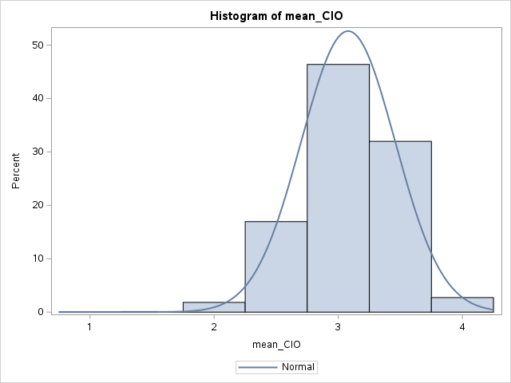

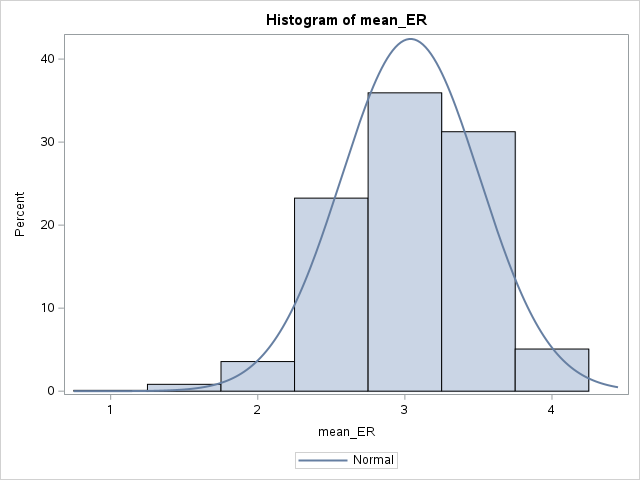

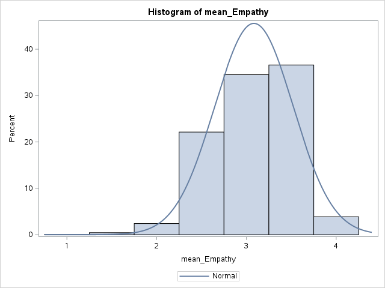

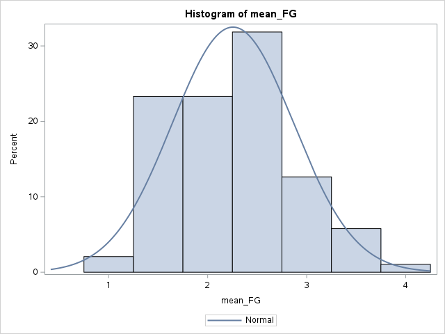

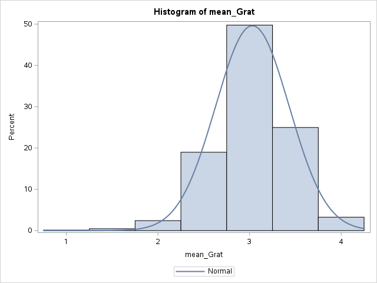

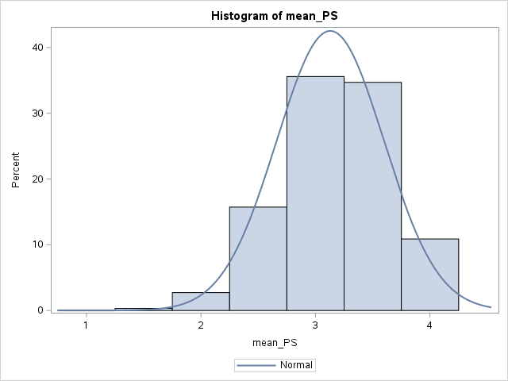

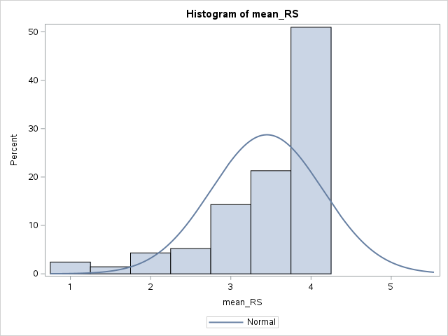

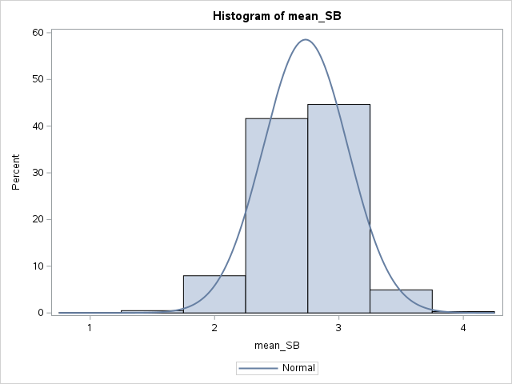

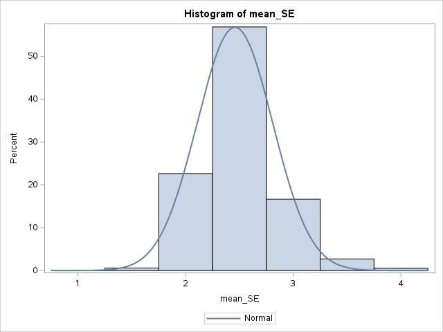

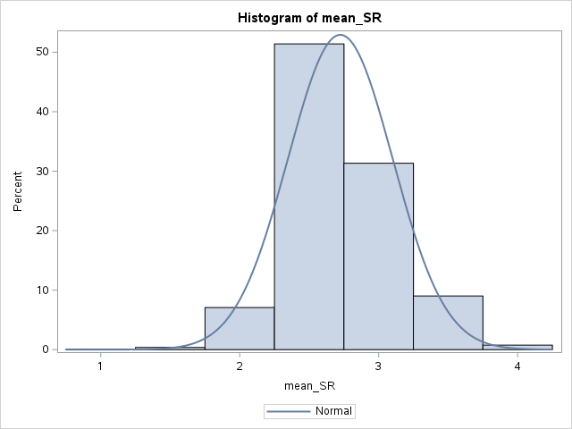

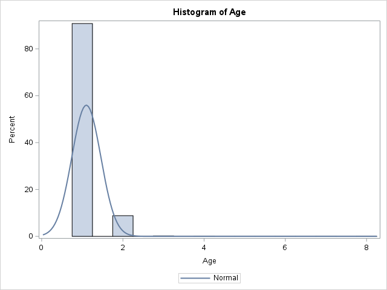

Histogram of Age

The FREQ Procedure

| Age | Frequency | Percent |
| --- | --- | --- |
| 1 | 6495 | 90.81 |
| 2 | 631 | 8.82 |
| 3 | 15 | 0.21 |
| 4 | 5 | 0.07 |
| 6 | 1 | 0.01 |
| 7 | 2 | 0.03 |
| 8 | 3 | 0.04 |

Histogram of Age

The CONTENTS Procedure

| Data Set Name | WORK.CONSTRUCT_MEAN_ONLY_AGE1 | Observations | 6495 |
| --- | --- | --- | --- |
| Member Type | DATA | Variables | 13 |
| Engine | V9 | Indexes | 0 |
| Created | 03/19/2025 21:11:47 | Observation Length | 104 |
| Last Modified | 03/19/2025 21:11:47 | Deleted Observations | 0 |
| Protection |  | Compressed | NO |
| Data Set Type |  | Sorted | NO |
| Label |  |  |  |
| Data Representation | SOLARIS_X86_64, LINUX_X86_64, ALPHA_TRU64, LINUX_IA64 |  |  |
| Encoding | utf-8 Unicode (UTF-8) |  |  |

| Engine/Host Dependent Information |  |
| --- | --- |
| Data Set Page Size | 131072 |
| Number of Data Set Pages | 6 |
| First Data Page | 1 |
| Max Obs per Page | 1258 |
| Obs in First Data Page | 1225 |
| Number of Data Set Repairs | 0 |
| Filename | /saswork/SAS_work68B200015B8D_odaws02-usw2.oda.sas.com/SAS_workD5AE00015B8D_odaws02-usw2.oda.sas.com/construct_mean_only_age1.sas7bdat |
| Release Created | 9.0401M7 |
| Host Created | Linux |
| Inode Number | 536913038 |
| Access Permission | rw-r--r-- |
| Owner Name | u64189948 |
| File Size | 896KB |
| File Size (bytes) | 917504 |

| Alphabetic List of Variables and Attributes # | Alphabetic List of Variables and Attributes Variable | Alphabetic List of Variables and Attributes Type | Alphabetic List of Variables and Attributes Len | Alphabetic List of Variables and Attributes Format | Alphabetic List of Variables and Attributes Informat |
| --- | --- | --- | --- | --- | --- |
| 1 | Age | Num | 8 | BEST12. | BEST32. |
| 2 | mean_CIO | Num | 8 |  |  |
| 3 | mean_ER | Num | 8 |  |  |
| 4 | mean_Empathy | Num | 8 |  |  |
| 5 | mean_FG | Num | 8 |  |  |
| 6 | mean_Grat | Num | 8 |  |  |
| 7 | mean_Hope | Num | 8 |  |  |
| 8 | mean_MM | Num | 8 |  |  |
| 9 | mean_PS | Num | 8 |  |  |
| 10 | mean_RS | Num | 8 |  |  |
| 11 | mean_SB | Num | 8 |  |  |
| 12 | mean_SE | Num | 8 |  |  |
| 13 | mean_SR | Num | 8 |  |  |

Histogram of Age

The CONTENTS Procedure

| Data Set Name | WORK.CONSTRUCT_MEAN_ONLY_AGE1_FINAL | Observations | 6495 |
| --- | --- | --- | --- |
| Member Type | DATA | Variables | 12 |
| Engine | V9 | Indexes | 0 |
| Created | 03/19/2025 21:11:47 | Observation Length | 96 |
| Last Modified | 03/19/2025 21:11:47 | Deleted Observations | 0 |
| Protection |  | Compressed | NO |
| Data Set Type |  | Sorted | NO |
| Label |  |  |  |
| Data Representation | SOLARIS_X86_64, LINUX_X86_64, ALPHA_TRU64, LINUX_IA64 |  |  |
| Encoding | utf-8 Unicode (UTF-8) |  |  |

| Engine/Host Dependent Information |  |
| --- | --- |
| Data Set Page Size | 131072 |
| Number of Data Set Pages | 5 |
| First Data Page | 1 |
| Max Obs per Page | 1363 |
| Obs in First Data Page | 1329 |
| Number of Data Set Repairs | 0 |
| Filename | /saswork/SAS_work68B200015B8D_odaws02-usw2.oda.sas.com/SAS_workD5AE00015B8D_odaws02-usw2.oda.sas.com/construct_mean_only_age1_final.sas7bdat |
| Release Created | 9.0401M7 |
| Host Created | Linux |
| Inode Number | 536884114 |
| Access Permission | rw-r--r-- |
| Owner Name | u64189948 |
| File Size | 768KB |
| File Size (bytes) | 786432 |

| Alphabetic List of Variables and Attributes # | Alphabetic List of Variables and Attributes Variable | Alphabetic List of Variables and Attributes Type | Alphabetic List of Variables and Attributes Len |
| --- | --- | --- | --- |
| 1 | mean_CIO | Num | 8 |
| 2 | mean_ER | Num | 8 |
| 3 | mean_Empathy | Num | 8 |
| 4 | mean_FG | Num | 8 |
| 5 | mean_Grat | Num | 8 |
| 6 | mean_Hope | Num | 8 |
| 7 | mean_MM | Num | 8 |
| 8 | mean_PS | Num | 8 |
| 9 | mean_RS | Num | 8 |
| 10 | mean_SB | Num | 8 |
| 11 | mean_SE | Num | 8 |
| 12 | mean_SR | Num | 8 |

Linear Regression Analysis: Predicting mean_SE

The REG Procedure

Model: MODEL1

Dependent Variable: mean_SE

| Number of Observations Read | 6495 |
| --- | --- |
| Number of Observations Used | 6495 |

| Analysis of Variance Source | Analysis of Variance DF | Analysis of Variance Sum of Squares | Analysis of Variance Mean Square | Analysis of Variance F Value | Analysis of Variance Pr > F |
| --- | --- | --- | --- | --- | --- |
| Model | 10 | 143.99797 | 14.39980 | 145.87 | <.0001 |
| Error | 6484 | 640.05882 | 0.09871 |  |  |
| Corrected Total | 6494 | 784.05679 |  |  |  |

| Root MSE | 0.31419 | R-Square | 0.1837 |
| --- | --- | --- | --- |
| Dependent Mean | 2.45049 | Adj R-Sq | 0.1824 |
| Coeff Var | 12.82141 |  |  |

| Parameter Estimates Variable | Parameter Estimates DF | Parameter Estimates Parameter Estimate | Parameter Estimates Standard Error | Parameter Estimates t Value | Parameter Estimates Pr > \|t\| |
| --- | --- | --- | --- | --- | --- |
| Intercept | 1 | 0.79671 | 0.04772 | 16.70 | <.0001 |
| mean_CIO | 1 | 0.16248 | 0.01257 | 12.92 | <.0001 |
| mean_ER | 1 | -0.02962 | 0.01006 | -2.95 | 0.0032 |
| mean_Empathy | 1 | -0.02303 | 0.01122 | -2.05 | 0.0401 |
| mean_FG | 1 | 0.05530 | 0.00649 | 8.53 | <.0001 |
| mean_Grat | 1 | 0.02302 | 0.01099 | 2.09 | 0.0362 |
| mean_MM | 1 | 0.05758 | 0.01113 | 5.18 | <.0001 |
| mean_PS | 1 | -0.00751 | 0.01065 | -0.71 | 0.4805 |
| mean_RS | 1 | 0.00104 | 0.00622 | 0.17 | 0.8671 |
| mean_SB | 1 | 0.11534 | 0.01430 | 8.06 | <.0001 |
| mean_SR | 1 | 0.24234 | 0.01155 | 20.98 | <.0001 |

Linear Regression Analysis: Predicting mean_SE

The REG Procedure

Model: MODEL1

Dependent Variable: mean_SE

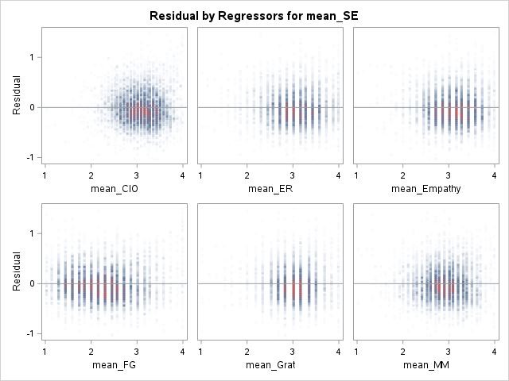

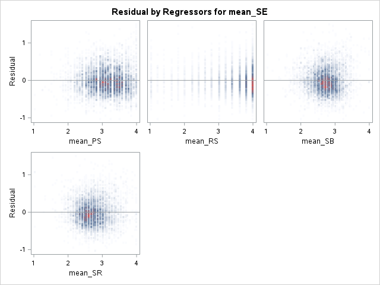

Linear Regression Analysis: Predicting mean_SE with Residuals

The REG Procedure

Model: MODEL1

Dependent Variable: mean_SE

| Number of Observations Read | 6495 |
| --- | --- |
| Number of Observations Used | 6495 |

| Analysis of Variance Source | Analysis of Variance DF | Analysis of Variance Sum of Squares | Analysis of Variance Mean Square | Analysis of Variance F Value | Analysis of Variance Pr > F |
| --- | --- | --- | --- | --- | --- |
| Model | 10 | 143.99797 | 14.39980 | 145.87 | <.0001 |
| Error | 6484 | 640.05882 | 0.09871 |  |  |
| Corrected Total | 6494 | 784.05679 |  |  |  |

| Root MSE | 0.31419 | R-Square | 0.1837 |
| --- | --- | --- | --- |
| Dependent Mean | 2.45049 | Adj R-Sq | 0.1824 |
| Coeff Var | 12.82141 |  |  |

| Parameter Estimates Variable | Parameter Estimates DF | Parameter Estimates Parameter Estimate | Parameter Estimates Standard Error | Parameter Estimates t Value | Parameter Estimates Pr > \|t\| |
| --- | --- | --- | --- | --- | --- |
| Intercept | 1 | 0.79671 | 0.04772 | 16.70 | <.0001 |
| mean_CIO | 1 | 0.16248 | 0.01257 | 12.92 | <.0001 |
| mean_ER | 1 | -0.02962 | 0.01006 | -2.95 | 0.0032 |
| mean_Empathy | 1 | -0.02303 | 0.01122 | -2.05 | 0.0401 |
| mean_FG | 1 | 0.05530 | 0.00649 | 8.53 | <.0001 |
| mean_Grat | 1 | 0.02302 | 0.01099 | 2.09 | 0.0362 |
| mean_MM | 1 | 0.05758 | 0.01113 | 5.18 | <.0001 |
| mean_PS | 1 | -0.00751 | 0.01065 | -0.71 | 0.4805 |
| mean_RS | 1 | 0.00104 | 0.00622 | 0.17 | 0.8671 |
| mean_SB | 1 | 0.11534 | 0.01430 | 8.06 | <.0001 |
| mean_SR | 1 | 0.24234 | 0.01155 | 20.98 | <.0001 |

Linear Regression Analysis: Predicting mean_SE with Residuals

The REG Procedure

Model: MODEL1

Dependent Variable: mean_SE

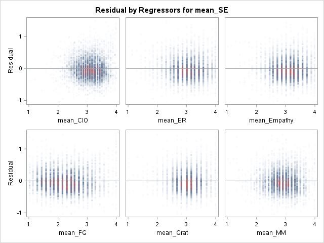

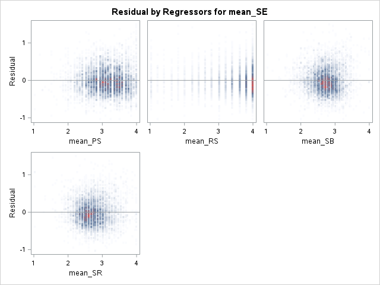

QQ Plot and Histogram of Residuals

The UNIVARIATE Procedure

Variable: Residual (Residual)

| Moments |  |  |  |
| --- | --- | --- | --- |
| N | 6495 | Sum Weights | 6495 |
| Mean | 0 | Sum Observations | 0 |
| Std Deviation | 0.31394517 | Variance | 0.09856157 |
| Skewness | 0.50653076 | Kurtosis | 0.78207288 |
| Uncorrected SS | 640.058818 | Corrected SS | 640.058818 |
| Coeff Variation | . | Std Error Mean | 0.00389551 |

| Basic Statistical Measures Location | Basic Statistical Measures Location | Basic Statistical Measures Variability | Basic Statistical Measures Variability |
| --- | --- | --- | --- |
| Mean | 0.00000 | Std Deviation | 0.31395 |
| Median | -0.02796 | Variance | 0.09856 |
| Mode | 0.44543 | Range | 2.56936 |
|  |  | Interquartile Range | 0.39667 |

| Tests for Location: Mu0=0 Test | Tests for Location: Mu0=0 Statistic | Tests for Location: Mu0=0 Statistic | Tests for Location: Mu0=0 p Value | Tests for Location: Mu0=0 p Value |
| --- | --- | --- | --- | --- |
| Student's t | t | 0 | Pr > \|t\| | 1.0000 |
| Sign | M | -235.5 | Pr >= \|M\| | <.0001 |
| Signed Rank | S | -544884 | Pr >= \|S\| | 0.0003 |

| Tests for Normality Test | Tests for Normality Statistic | Tests for Normality Statistic | Tests for Normality p Value | Tests for Normality p Value |
| --- | --- | --- | --- | --- |
| Kolmogorov-Smirnov | D | 0.047904 | Pr > D | <0.0100 |
| Cramer-von Mises | W-Sq | 4.064363 | Pr > W-Sq | <0.0050 |
| Anderson-Darling | A-Sq | 23.56557 | Pr > A-Sq | <0.0050 |

| Quantiles (Definition 5) Level | Quantiles (Definition 5) Quantile |
| --- | --- |
| 100% Max | 1.5265280 |
| 99% | 0.8569350 |
| 95% | 0.5619051 |
| 90% | 0.4046134 |
| 75% Q3 | 0.1841348 |
| 50% Median | -0.0279611 |
| 25% Q1 | -0.2125395 |
| 10% | -0.3673893 |
| 5% | -0.4562677 |
| 1% | -0.6797273 |
| 0% Min | -1.0428277 |

| Extreme Observations Lowest Value | Extreme Observations Lowest Obs | Extreme Observations Highest Value | Extreme Observations Highest Obs |
| --- | --- | --- | --- |
| -1.042828 | 6210 | 1.35244 | 3538 |
| -1.007432 | 1335 | 1.36332 | 1441 |
| -1.006536 | 375 | 1.41546 | 6433 |
| -0.952102 | 819 | 1.48403 | 5465 |
| -0.926019 | 2739 | 1.52653 | 3446 |

QQ Plot and Histogram of Residuals

The UNIVARIATE Procedure

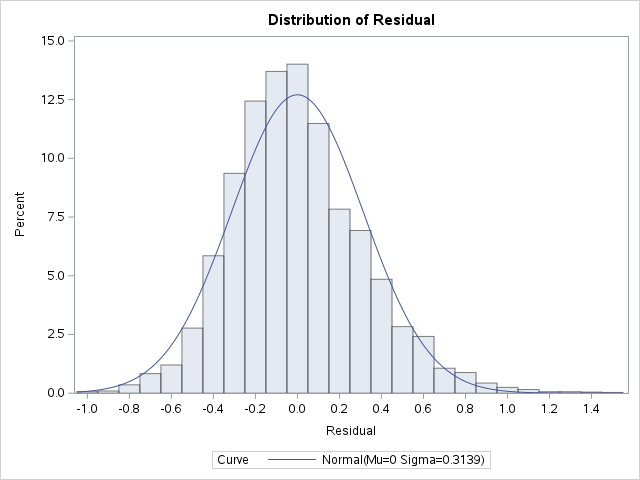

QQ Plot and Histogram of Residuals

The UNIVARIATE Procedure

Fitted Normal Distribution for Residual (Residual)

| Parameters for Normal Distribution Parameter | Parameters for Normal Distribution Symbol | Parameters for Normal Distribution Estimate |
| --- | --- | --- |
| Mean | Mu | 0 |
| Std Dev | Sigma | 0.313945 |

| Goodness-of-Fit Tests for Normal Distribution Test | Goodness-of-Fit Tests for Normal Distribution Statistic | Goodness-of-Fit Tests for Normal Distribution Statistic | Goodness-of-Fit Tests for Normal Distribution p Value | Goodness-of-Fit Tests for Normal Distribution p Value |
| --- | --- | --- | --- | --- |
| Kolmogorov-Smirnov | D | 0.0479045 | Pr > D | <0.010 |
| Cramer-von Mises | W-Sq | 4.0643626 | Pr > W-Sq | <0.005 |
| Anderson-Darling | A-Sq | 23.5655700 | Pr > A-Sq | <0.005 |

| Quantiles for Normal Distribution Percent | Quantiles for Normal Distribution Quantile Observed | Quantiles for Normal Distribution Quantile Estimated |
| --- | --- | --- |
| 1.0 | -0.67973 | -0.73035 |
| 5.0 | -0.45627 | -0.51639 |
| 10.0 | -0.36739 | -0.40234 |
| 25.0 | -0.21254 | -0.21175 |
| 50.0 | -0.02796 | 0.00000 |
| 75.0 | 0.18413 | 0.21175 |
| 90.0 | 0.40461 | 0.40234 |
| 95.0 | 0.56191 | 0.51639 |
| 99.0 | 0.85694 | 0.73035 |

QQ Plot and Histogram of Residuals

The UNIVARIATE Procedure

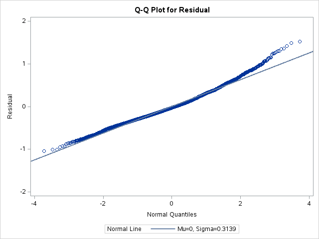

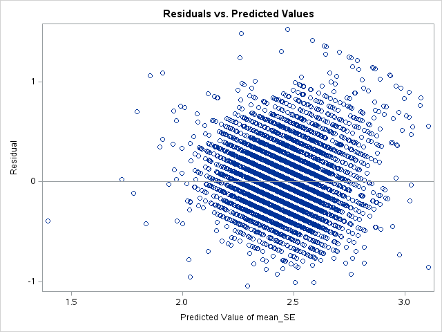